# Module 3 - ANOVA

TVZ

```r
# Upload the libraries used in this document
#library("ggplot2")
#library("tinytex")
#library("extraDistr")
#library("sysid")
library("DescTools")
library('effectsize')
# library('PairedData')
library('pwrss')
library('pwr')
#library("psych")
#library('multcomp')
```

This should be useful for you as a reference while you work on your own analysis problems, most of which will involve some kind of ANOVA or regression.

# Learning Objectives

Analysis of Variance (ANOVA) is a statistical method used to compare means across two or more groups to determine if there are any significant differences between those groups. We will first discuss the ANOVA model, then the process of *partitioning the variance*, which is the theoretical foundation for the ANOVA procedure. Following that, we will fit an ANOVA model and determine if a treatment has significant effects and perform diagnostics to determine if the assumptions of the ANOVA model are satisfied. Then we discuss the concepts of power and effect size, and how these concepts vary from the same concepts encountered in $z$- and $t$-tests. We will talk about post-hoc and planned contrasts, and end with the analysis of factorial and repeated measures designs.

At the end of this notebook you should be able to:

1. Identify scenarios in which Analysis of Variance (ANOVA) is the appropriate statistical tool for comparing means across multiple groups.
2. Identify the key assumptions of ANOVA (normality, homogeneity of variances, independence of observations) and explain the consequences of violating them.
3. Compute the F-statistic and explain how its magnitude relates to the rejection of the null hypothesis of equality of means.
4. Distinguish clearly between the application and interpretation of One-Way and Two-Way ANOVA.
5. Define a statistical interaction effect in the context of Two-Way ANOVA and explain why a significant interaction dictates the primary focus of interpretation.
6. Structure a dataset appropriately in `R` and use built-in `R` functions (or common packages like `aov` or `lm`) to execute both One-Way and Two-Way ANOVA.
7. Generate and interpret necessary diagnostic plots (e.g., Q-Q plots, residuals vs. fitted plots) to formally check the assumptions of the ANOVA model.
8. Summarize and report the key results of the ANOVA, including degrees of freedom, F-statistic, and p-value, in an academic or report-ready format.
9. Explain the difference between planned (a priori) contrasts and post-hoc tests, and justify when to use each approach based on the research question.
10. Apply a common post-hoc procedure (such as Tukey’s HSD) using an appropriate `R` package and interpret the resulting pairwise comparisons.
11. Formulate specific hypotheses and assign appropriate contrast coefficients to test targeted comparisons between means (e.g., simple, repeated, or polynomial contrasts).
12. Recognize the problem of inflated Type I error due to multiple comparisons and explain the rationale behind common correction methods (e.g., Bonferroni, Holm).
13. Identify main effects and interactions from a plot of condition means.
14. Perform a factorial ANOVA for data from experimental designs with more than 1 categorical predictor variables.
15. Perform a repeated measures ANOVA for data from experimental designs with a single repeated categorical predictor variable.

# Upload GSS Data

```r
data <- read.csv("GSS_1980.csv",header=TRUE)
data$X <- NULL
```

# Introduction to ANOVA

The hypothesis tests that we have considered up to this point have been focused on only one or two means, with the goal of arguing against the hypothesis that either one mean comes from a sample from a population with a stated null mean $\mu_0$ or that the difference between two means is due to sampling variability (chance: $\mu_1 = \mu_2$). But what about the situation where we have two or more means?

ANOVA examines how a (numeric) dependent variable changes across levels of one or more *categorical* independent variables. For example, consider the GSS_1980 dataset. Let’s look at respondents’ income as a function of their reported health.

```r
# Pull out variables of interest
money <- data$REALRINC
siblings <- data$SIBS
age <- data$AGE
happy <- data$HAPPY

# Make sure the health and happiness ratings are categorical (super important)
health <- as.factor(data$HEALTH)
happy <- as.factor(data$HAPPY)

# Redefine the data object
data <- data.frame("money" = money,"health"= health,"age"=age,"siblings"=siblings,"happy"=happy)
```

Let’s focus on respondents’ age as a function of reported health, under the assumption that people who report poor health (health=4) will tend to be older than those who report good health (health < 4).

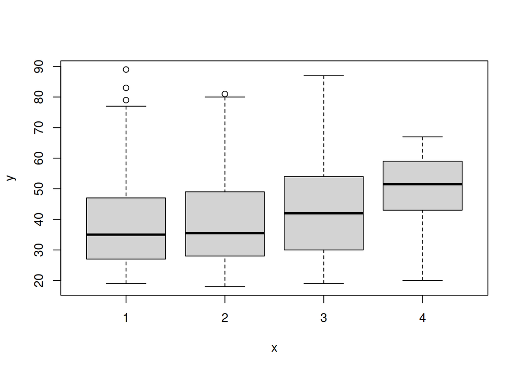

```r
# Plot age as a function of health
plot(health,age)
```

This *box and whisker* chart tends to confirm our suspicions about the relationship between age and reported health. But we would like to say that the differences in the means across levels of reported health are *significantly* different. To do this we will perform an analysis of variance (ANOVA).

The ANOVA null hypothesis is
$$H_0: \mu_1 = \mu_2 = \cdots = \mu_J$$
for $J$ groups or $J$ *levels* of an independent variable. This hypothesis is called the *omnibus null*: we’re going to design a test for equality of all the groups in our experiment. The alternative to this hypothesis is
$$H_1: \text{ At least one } \mu_j \text{ is different from the others}.$$

When we reject $H_0$ we will not know why we rejected it: ANOVA alone will not tell us much about what’s going on in each group. We’ll need to do other things to figure that out (we’ll discuss these things later).

### 1. Your turn!

Using your own dataset, select the dependent variable and a categorical independent variable with at least 3 levels. Create a box-and-whisker plot of the dependent variable as a function of the independent variable. State your null and alternative hypotheses for an ANOVA test of equality of means across the levels of your independent variable.

```r
# Insert your code here
```

## Can’t We Just Do $t$-Tests?

Your immediate instinct (coming off of several weeks of doing nothing but $t$-tests) might be that the way to test
$$H_0: \mu_1 = \mu_2 = \cdots = \mu_J$$
is to contrast all pairs of means across the $J$ groups by doing $\binom{J}{2} = J(J-1)/2$ independent samples $t$-tests. While this might not be a bad idea, it has one serious shortcoming. What is the probability of making at least one Type I error across all of those pairwise tests? That is, if we want our probability of erroneously rejecting $H_0: \mu_i = \mu_j$ for one or more pairs of means not to exceed $\alpha$, will the pairwise $t$-test strategy be the best approach?

Assume that $J=4$. Then $\binom{4}{2} = \dfrac{4 \cdot 3}{2} = 6$. For each of those 6 tests we’ll set $\alpha = 0.05$. The probability of *not* making a Type I error on any one test is $1 - \alpha = 0.95$. Under the assumption of independence across the groups (which we need for the independent samples $t$-test *and* the ANOVA), the probability of not making a single Type I error across the 6 tests is $(1 - \alpha)^6$. Conversely, the probability of making one or more Type I errors is $1 - (1 - \alpha)^6$.

Because $1 - \alpha$ is less than 1, raising it to higher and higher powers results in a smaller and smaller probability of not making an error. In turn, the probability of making an error must therefore increase for all values of $\alpha < 1$.

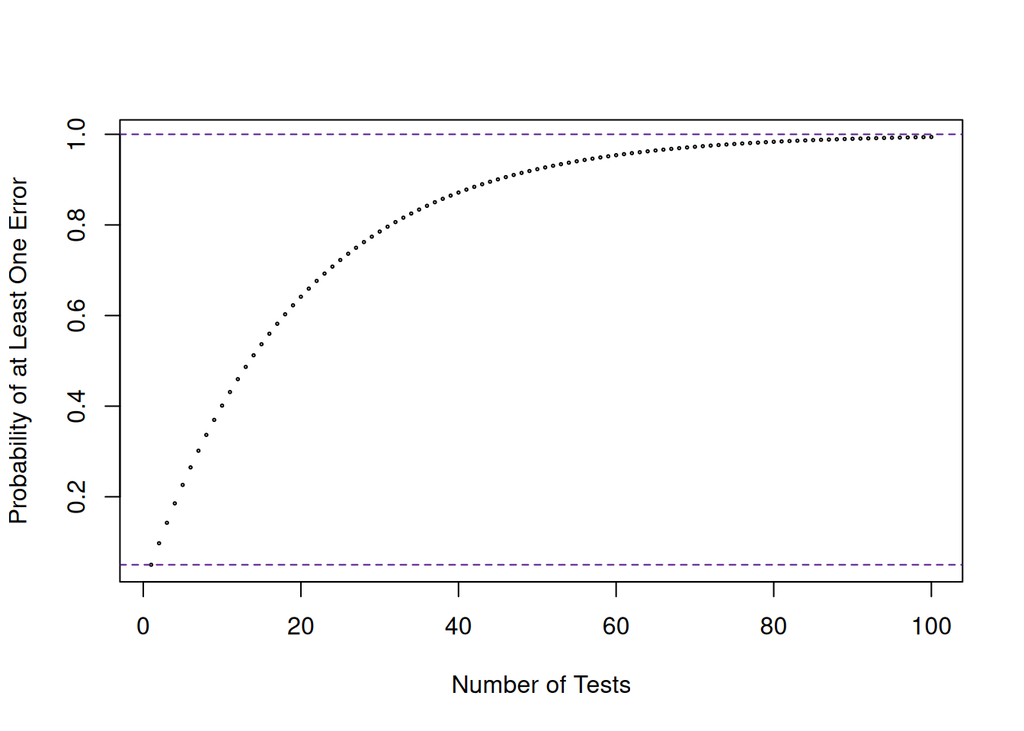

```r
M <- 1:100 # number of tests
alpha = 0.05

# Probability of at least one error
prob.1 <- 1 - (1 - alpha)^M

plot(M,prob.1,type='p',xlab="Number of Tests",ylab="Probability of at Least One Error",cex=.25)
abline(h=c(0.05,1.0),col='purple4',lty=2)
```

This graph shows the probability of making at least one Type I error when $\alpha=0.05$ as a function of the number of pairwise tests to be performed. This probability grows quickly with the number of tests to be performed. By the time the number of tests reaches 14 the probability is greater than half. By the time it reaches 59 the probability is greater than 95%. Fourteen tests corresponds to around $J=6$ groups; 59 tests corresponds to $J=12$ groups (more than you should be considering in a single experimental design). Bottom line: pairwise $t$-testing is not a good solution for testing equality of more than two means.

This $t$-test strategy (pairwise $t$-testing) is something we will encounter later in the form of post-hoc testing. Here, however, we will consider an alternative strategy (ANOVA) that “rewrites” the null hypothesis $H_0$ as a question about variances rather than means. Remember that the F-distribution describes the random variable that arises from a ratio of two variances and that the F-test is used to examine the hypothesis $H_0: \sigma^2_1 = \sigma^2_2$, or equivalently $H_0: \sigma^2_1/\sigma^2_2 = 1$.

## The Logic of ANOVA

Consider the distribution of age measurements across the four health levels.

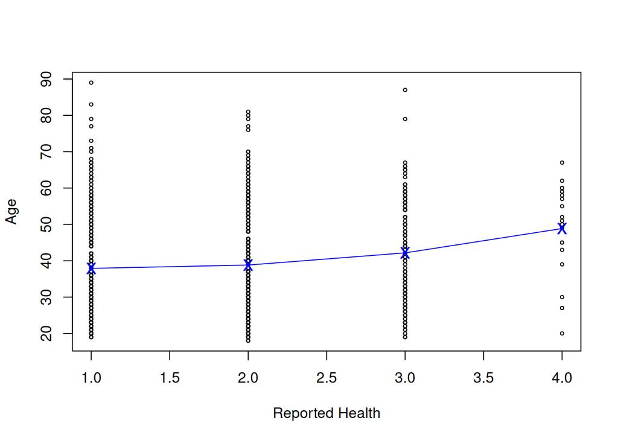

```r
# Plot age as a function of reported health
plot(age~as.numeric(health),xlab="Reported Health",ylab="Age",cex=.5)

# Add the means of each group to the plot
means <- aggregate(age,by=list(health),mean)
points(means$Group.1,means$x,pch='x',col='blue',cex=1.5)
lines(means$Group.1,means$x,col='blue')
```

We are interested in whether the mean ages at each level of reported health are different. The blue Xs mark the group means that are the focus of our attention. Remember that (almost) every statistical procedure is based on a *model*, an assumption about how the data were generated. (Some models are more interesting than others.) You need to understand the ANOVA model before we proceed.

# The ANOVA Model

Write $X_{ij}$ to indicate the age of respondent $i$ in group $j$. The ANOVA model states that every observation $X_{ij}$ within group $j$ should be approximately equal to the mean $\mu_j$ of the population from which that group was sampled, plus some amount of noise $e_{ij}$. So $X_{ij} = \mu_j + e_{ij}$, where $e_{ij} \sim \mathcal{N}(0,\sigma^2_e)$. We assume that the $e_{ij}$s are independent and identically distributed with common variance $\sigma^2_e$. This means the $X_{ij}$s must also be independent and normally distributed with mean $\mu_j$ and variance $\sigma^2_e$. We call $\sigma^2_e$ the error variance: the only reason that $X_{ij}$ doesn’t exactly equal $\mu_j$ is because of sampling error. An important thing to recognize is that error is inexplicable. We don’t know where it comes from, only that it makes things messy.

Notice the homoskedasticity assumption: the error variance $\sigma^2_e$ is the same for each group. If the null hypothesis $H_0: \mu_1 = \mu_2 = \cdots = \mu_J$ is true and all the means are the same, and if the samples all come from populations with variance $\sigma^2_e$, then the samples have all been drawn from the same normal distribution with mean $\mu = \mu_j,~j=1,\ldots,J$, called the *grand mean*, and variance $\sigma^2_e$.

For reasons that will become clear later, we can rewrite the model by adding zero as
$$X_{ij} = \mu + (\mu_j - \mu) + e_{ij} = \mu + \tau_j + e_{ij},$$
where $\tau_j = \mu_j - \mu$ is called the *effect* of being in group $j$ (sometimes called the effect of treatment level $j$). If $H_0$ is true, all the effects are zero, because $\mu=\mu_j$ for all $j$.

These are the most important assumptions about the ANOVA model:

1. All groups are independent.
2. Individuals are randomly assigned to treatment conditions.
3. The measurements $X_{ij}$ are normally distributed.
4. The error variance $\sigma^2_e$ is the same over all groups (homoskedasticity).

The ANOVA model predicts that each individual’s measurement should be equal to the population mean for the group to which the individual was assigned. We don’t know what $\mu_j$ is so we will estimate it with the group mean $\overline{X}_j$. This means that the predicted measurement for each individual in group $j$ is $\overline{X}_j$.

Go back to the figure in the code chunk `ANOVA logic`. The ANOVA model allows us to reformulate the null hypothesis of equality of means in terms of predicted and error variance. If $H_0$ is true, the predicted variance, the variance of all the predicted scores, should be approximately the same as the error or unexplained variance. To see how this is true, we need to *partition* the total variance in the measured variable.

## Partitioning Variance

Consider the age variable in the GSS dataset. To begin, we will look at the variance of age without reference to the reported health of any of the respondents. This is the *total variance*:

```r
# Total variance of age
var(data$age)
```

```
## [1] 196.1881
```

Remember that the variance of a set of measurements is the sum of squared deviations of the measurements from the group mean divided by the degrees of freedom, or
$$s^2 = \dfrac{\sum_{i=1}^N (X_i - \overline{X})^2}{N-1}.$$

For the rest of this discussion we will focus on the sum of squares $SSX = \sum_{i=1}^N (X_i - \overline{X})^2$, the numerator of the variance of $X$. When we look at the sum of squares of a variable over all observations of that variable without regard to the experimental design or who is assigned to which group we call it the *total* sum of squares. Call $N_{\text{Total}}$ the total number of respondents and $SS_{\text{Total}}$ the total sum of squares.

```r
N.Total <- length(age) # all the ages
SS.Total <- var(age)*(N.Total - 1) # the numerator of the total variance
```

Now we need to modify our notation a bit to take into account the fact that associated with each respondent’s age there is also a reported health. Use the subscript index $i$ to indicate a particular respondent and a second subscript index $j$ to refer to the health “group” they are in, so the age of respondent $i$ with reported health $j$ is $X_{ij}$. Each group $j=1,2,\ldots,J$ has $N_j$ respondents in it, and the number of groups is $J$ (which equals 4 in this case, but we’ll just write $J$ to keep things as general as possible). So the respondents in group $j$ are $i = 1, 2, \ldots, N_j$.

Within each group $j$ we can compute the group mean $\overline{X}_j$ and group variance $s^2_j$ in the usual way:
$$\overline{X}_j = \dfrac{\sum_{i=1}^{N_j} X_{ij}}{N_j},$$
and
$$s^2_j = \dfrac{\sum_{i=1}^{N_j} (X_{ij} - \overline{X}_j)^2}{N_j - 1}.$$

```r
# Compute the group statistics and store them in vectors
group.means <- aggregate(age,by=list(health),mean)
group.vars <- aggregate(age,by=list(health),var)

# Examine the group characteristics
Desc(age~health)
```

```
## ──────────────────────────────────────────────────────────────────────────────
## age ~ health
##
## Summary:
## n pairs: 873, valid: 873 (100.0%), missings: 0 (0.0%), groups: 4
##
##
##               1        2        3        4
## mean     37.909   38.820   42.167   48.864
## median   35.000   35.500   42.000   51.500
## sd       13.669   13.942   14.280   13.072
## IQR      20.000   21.000   24.000   15.500
## n           319      400      132       22
## np      36.541%  45.819%  15.120%   2.520%
## NAs           0        0        0        0
## 0s            0        0        0        0
##
## Kruskal-Wallis rank sum test:
##   Kruskal-Wallis chi-squared = 19.817, df = 3, p-value = 0.0001852
```

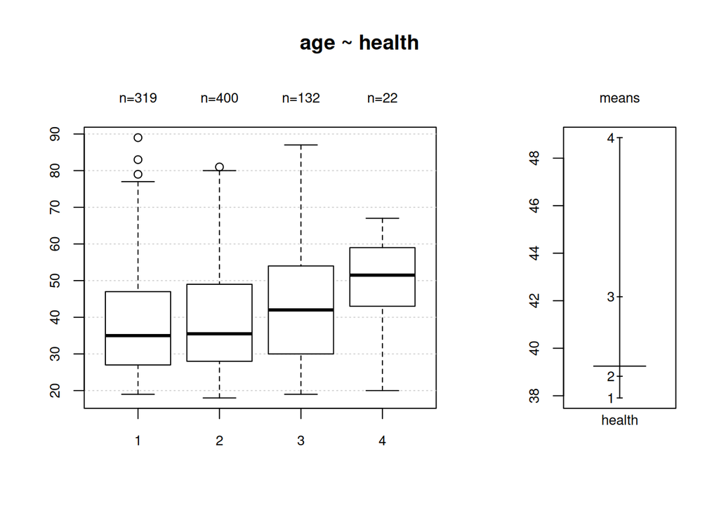

(The `Desc()` function from the `DescTools` package provides a nice summary of the group statistics, including the group means and variances, the group sizes, a box-and-whisker plot of age as a function of health, and a plot of the group means. It also gives the results of a Kruskal-Wallis test, which is a nonparametric alternative to ANOVA. You don’t know yet what a Kruskal-Wallis test is, but you can probably guess from the $p$-value it returns that there are significant differences among the group means.)

We need to also compute the “grand mean” $\overline{\overline{X}}$, the mean of all the ages across all the groups. If all the group sizes $N_j$ are equal we can express the grand mean as the mean of the means, or
$$\overline{\overline{X}} = \dfrac{\sum_{j=1}^J \overline{X_j}}{k}.$$
However, if the group sizes are not equal then we have to weight each group mean by the group size. To do this you can work backward from the group means using the formula for a [weighted mean](https://en.wikipedia.org/wiki/Weighted_arithmetic_mean) or just compute the mean over all the individual observations. Our notation for this requires an additional summation sign:
$$\overline{\overline{X}} = \dfrac{\sum_{j=1}^J \sum_{i=1}^{N_j}
X_{ij}}{N_{\text{Total}}}.$$
It shouldn’t be hard to figure out this notational twist: set $j=1$ for the first group and add up all the values in the group ($X_{i,1}$). Then increment $j=2$ and add up all the values in the second group and add that to the sum of the first group. Continue incrementing $j$ until you’ve added up all the values of the variable.

```r
# Grand mean when groups are equal or unequal
grand.mean <- mean(age)
```

Now rewrite the total sums of squares $SS_{\text{Total}}$ using this new notation by adding up the squared deviations within the first group, then the second, and so on. Then $SS_{\text{Total}}$ becomes
$$SS_{\text{Total}} = \sum_{j=1}^J \sum_{i=1}^{N_j} (X_{ij} -
\overline{\overline{X}})^2.$$

Let’s go back to the figure and focus in on one respondent’s measurement in particular, which I’ve colored in orange. I’ve also added the grand mean to the plot (the horizontal dashed line).

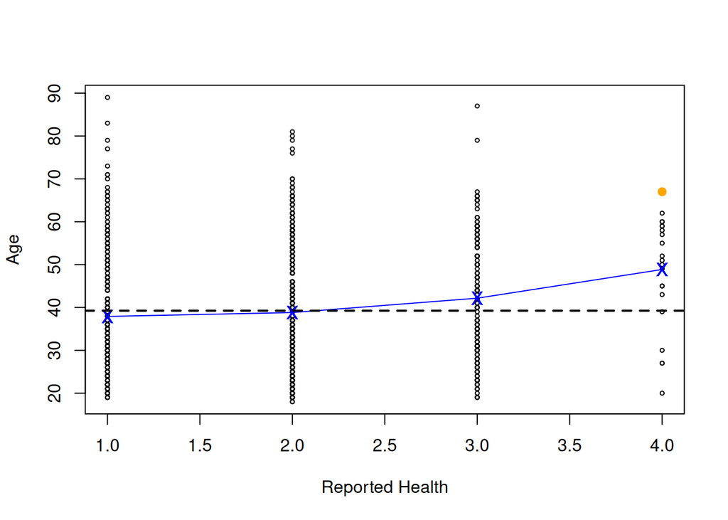

```r
# Plot age as a function of reported health
plot(age~as.numeric(health),xlab="Reported Health",ylab="Age",cex=.5)

# Add the means of each group to the plot
points(group.means$Group.1,group.means$x,pch='x',col='blue',cex=1.5)
lines(group.means$Group.1,group.means$x,col='blue')
abline(h=mean(age),lty=2,lwd=2) # grand mean

# Highlight observation 619
unsub <- 619
points(health[unsub],age[unsub],pch=19,col='orange',cex=1)
```

ANOVA decomposes total variance into: 1. **Between-group variance** (explained by group differences) 2. **Within-group variance** (residual or error)

The total deviation of respondent 619’s age $X_{619,4}$ from the grand mean $\overline{\overline{X}}$ can be broken down into two components: the difference between Group 4’s mean $\overline{X}_4$ from the grand mean $\overline{\overline{X}}$ – the difference between the blue X and the horizontal dashed line, between-group deviation – and the difference between the individual’s age $X_{619,4}$ from the group mean $\overline{X}_4$ – the difference between the orange dot and the blue X, within-group deviation. Mathematically, this is expressed as
$$X_{ij} - \overline{\overline{X}} = (\overline{X}_j -
\overline{\overline{X}}) + (X_{ij} - \overline{X}_j).$$

Squaring both sides and summing over all respondents and all groups gives
$$\begin{eqnarray*}
\sum_{j=1}^J \sum_{i=1}^{N_j} (X_{ij} - \overline{\overline{X}})^2 &
= & \sum_{j=1}^J \sum_{i=1}^{N_j} (\overline{X}_j -
\overline{\overline{X}})^2 + \sum_{j=1}^J \sum_{i=1}^{N_j} 2
(\overline{X}_j - \overline{\overline{X}})(X_{ij} - \overline{X}_j) +
\sum_{j=1}^J \sum_{i=1}^{N_j} (X_{ij} - \overline{X}_j)^2 \\
& = & \sum_{j=1}^J \sum_{i=1}^{N_j} (\overline{X}_j -
\overline{\overline{X}})^2 + 2 \sum_{j=1}^J (\overline{X}_j -
\overline{\overline{X}}) \sum_{i=1}^{N_j} (X_{ij} - \overline{X}_j) +
\sum_{j=1}^J \sum_{i=1}^{N_j} (X_{ij} - \overline{X}_j)^2 \\
& = & \sum_{j=1}^J \sum_{i=1}^{N_j} (\overline{X}_j -
\overline{\overline{X}})^2 + \sum_{j=1}^J \sum_{i=1}^{N_j} (X_{ij} -
\overline{X}_j)^2.
\end{eqnarray*}$$

The term in the middle that is multiplied by 2 that we get after expanding the product on the right side is zero because the sum of deviations from the group mean $\sum_{i=1}^{N_j} \left( X_{ij} - \overline{X}_j \right)$ is always zero.

The left side is the total sum of squares $SS_{\text{Total}}$. The first term on the right side is called the *between-groups* sum of squares $SS_{\text{Between}}$, which measures how much of the total variance is explained by differences between group means. The second term on the right side is called the *within-groups* sum of squares $SS_{\text{Within}}$, which measures the variance within each group that is not explained by group membership (the error variance). So we have
$$SS_{\text{Total}} = SS_{\text{Between}} +
SS_{\text{Within}}.$$
If we divide each term by their associated degrees of freedom, we say that the total variance is partitioned into variance explained by group differences and unexplained variance (error).

## Does this really work?

Compute the three sums of squares for the age variable.

```r
# Determine the numbers of observations and groups
N.total <- length(age) # all the ages
N.groups <- aggregate(age,by=list(health),length)$x
J <- length(N.groups) # number of groups

# Compute the means
grand.mean <- mean(age)
group.means <- aggregate(age,by=list(health),mean)$x

# Total sum of squares
SS.total <- sum((age - grand.mean)^2)

# Between-groups sum of squares
SS.between <- sum(N.groups * (group.means - grand.mean)^2)

# Within-groups sum of squares
SS.within <- sum(aggregate(age,by=list(health),
             function(x) sum((x - mean(x))^2))$x)
# Alternative:
# SS.within <- sum((N.groups - 1)*
#              aggregate(age,by=list(health),var)$x )

# Check that the sums of squares add up
cat('SS.total = ',SS.total)
```

```
## SS.total =  171076.1
```

```r
cat('\nSS.between = ',SS.between)
```

```
##
## SS.between =  3803.723
```

```r
cat('\nSS.within = ',SS.within)
```

```
##
## SS.within =  167272.3
```

```r
cat('\nSS.between + SS.within = ',SS.between + SS.within)
```

```
##
## SS.between + SS.within =  171076.1
```

## 2. Your turn!

Using your own dataset, compute the total, between-groups, and within-groups sums of squares for your dependent variable. Verify that the between and within sums of squares add up to the total.

```r
# Insert your code here
```

## The ANOVA F-Test

Remember that $\overline{X}_j$ is the predicted value for each individual in group $j$. For the between-groups variance (sometimes called predicted variance), we will replace all the individual measurements $X_{ij}$ with their predicted values $\overline{X}_j$. For the within-groups variance (sometimes called residual or error variance), we will focus on the extent to which the predicted values $\overline{X}_j$ differ from the actual measurements $X_{ij}$.

*If the null hypothesis is true*, the group means should be approximately equal or $\overline{\overline{X}} = \overline{X}_j$ for all $j$, so the only reason that any person’s score should differ from the grand mean $\overline{\overline{X}}$ is because of sampling variance or error. Therefore, the between-groups variance should estimate the population variance $\sigma^2_e$. Keep in mind that, under the assumption of homoskedasticity, the sample variances within each group are also estimates of $\sigma^2_e$, so the within-groups variance should also estimate $\sigma^2_e$. Thus, if $H_0$ is true, the between-groups variance and the within-groups variance should be approximately equal.

*If the null hypothesis is false*, at least one group mean $\overline{X}_j$ is different from the others, so the between-groups variance should be large relative to the within-groups variance. This leads us to the key idea behind ANOVA: we can test the null hypothesis of equality of means by comparing the between-groups variance to the within-groups variance. If the between-groups variance is significantly larger than the within-groups variance, we will reject $H_0$. If the two variances are approximately equal, we will fail to reject $H_0$. See the section below, “Back to the ANOVA Model,” for more about this.

To perform this comparison we need to convert the sums of squares into variances by dividing each sum of squares by its associated degrees of freedom. The between-groups variance has $J-1$ degrees of freedom (one less than the number of groups). This is because we are replacing each $X_{ij}$ with its group mean $\overline{X}_j$, and so the only degrees of freedom we have are selecting the values of the group means: the mean of these means must equal the grand mean $\overline{\overline{X}}$ and so the value of the last group mean is determined by the values of the other $J-1$ group means.

The within-groups variance has $N_{\text{Total}} - J$ degrees of freedom (the total number of observations minus the number of groups). Within each group we have $N_j - 1$ degrees of freedom as for the usual computation of a sample variance. The total degrees of freedom for the within-groups variance is therefore the sum of the degrees of freedom across all groups, or
$$\sum_{j=1}^J (N_j - 1) = \left(\sum_{j=1}^J N_j\right) - J =
N_{\text{Total}} - J.$$

Dividing each sum of squares by its degrees of freedom gives us the *mean square* for each source of variance:
$$MS_{\text{Between}} =
\dfrac{SS_{\text{Between}}}{J-1},$$
and
$$MS_{\text{Within}} =
\dfrac{SS_{\text{Within}}}{N_{\text{Total}} - J}.$$
These MS values give two different estimates of the variance $\sigma^2_e$ *if* $H_0$ is true. The null hypothesis
$$H_0: \mu_1 = \mu_2 = \cdots = \mu_J$$
can therefore be evaluated by the equivalent null hypothesis
$$H_0: \sigma^2_{\text{Between}} = \sigma^2_{\text{Within}}$$
or
$$H_0: \dfrac{\sigma^2_{\text{Between}}}{\sigma^2_{\text{Within}}} = 1.$$

Estimating the variances with the mean squares leads to the ANOVA $F$-statistic, which is the ratio of the mean squares:
$$F(J-1,N_{\text{Total}} - J) =
\dfrac{MS_{\text{Between}}}{MS_{\text{Within}}},$$
with $J-1$ numerator and $N_{\text{Total}} - J$ denominator degrees of freedom. If $H_0$ is true, this ratio should be approximately 1. If $H_0$ is false, the ratio should be significantly larger than 1.

# Fit an ANOVA Model

Going back to the GSS data, we can fit an ANOVA model for age as a function of reported health using the `aov()` function in R. The commands in this chunk fit the model (but we won’t see that yet) and produces a table of group means, group sizes, and the grand mean.

```r
# Fit a one-way ANOVA model
age.model <- aov(age~health,data=data)
model.tables(age.model, type = "means")
```

```
## Tables of means
## Grand mean
##
## 39.24628
##
##  health
##          1      2      3     4
##      37.91  38.82  42.17 48.86
## rep 319.00 400.00 132.00 22.00
```

## The ANOVA Summary Table

A lovely way to present the results of an ANOVA is via the ANOVA summary table, which can be obtained using the `summary()` function in `R`.

```r
summary(age.model)
```

```
##              Df Sum Sq Mean Sq F value  Pr(>F)
## health        3   3804  1267.9   6.587 0.00021 ***
## Residuals   869 167272   192.5
## ---
## Signif. codes:  0 '***' 0.001 '**' 0.01 '*' 0.05 '.' 0.1 ' ' 1
```

Summary tables are no longer as popular as they used to be, because they take up a lot of space and don’t convey much information beyond the $F$-statistic and the associated p-value. However, they do provide a nice way to see the partitioning of variance that is the foundation of ANOVA and to confirm that the computations that you think `R` is doing are correct.

In the summary table above, you can see the partitioning of variance into between-groups and within-groups components. The between-groups component is identified by the name of the independent variable (health), and the within-groups component is identified by the label “Residuals.” (Residual sum of squares is another name for within-groups sum of squares; you will also see it referred to as error sum of squares.)

You can verify for yourself that these sums of squares are the same as the ones we computed earlier and that the Residual and health sums of squares add up to the total sum of squares. Another thing to notice is that the degrees of freedom for each source of variance sum to the total degrees of freedom, $N_{\text{Total}} - 1 = (J-1) + (N_{\text{Total}} - J)$.

The $F$-statistic is the same that we would use to test the null hypothesis $H_0: \sigma_1^2 = \sigma_2^2$, so $F = s_1^2/s_2^2$, the ratio of two sample variances. In ANOVA, the sample variances that estimate the population variances $\sigma_{\text{Between}}$ and $\sigma_{\text{Within}}$ are $MS_{\text{Between}}$ and $MS_{\text{Within}}$, which should be approximately equal if $H_0: \mu_1 = \mu_2 = \cdots = \mu_J$ is true. Thus, the $F$-statistic is $MS_{\text{Between}}/MS_{\text{Within}}$. This statistic follows an $F$-distribution with $J-1$ numerator and $N_{\text{Total}} - J$ denominator degrees of freedom.

The degrees of freedom (Df) for the numerator and denominator of the $F$-statistic and p-value are presented in the summary table. The probability of obtaining an $F$-statistic as large or larger than the observed value under the null hypothesis is very small ($p$-value < $\alpha$, if $\alpha = 0.05$), so we reject the null hypothesis of equality of means across reported health levels and conclude that at least one group mean is different from the others.

## 3. Your turn!

Using your own dataset, fit an ANOVA model for your dependent variable as a function of your categorical independent variable. Present the ANOVA summary table and interpret the results.

```r
# Insert your code here
```

## Back to the ANOVA Model

Remember that the ANOVA model predicting $X$ from the group means can be written as
$$X_{ij} = \mu + \tau_j + e_{ij},$$
where we defined $\mu$ to be the grand mean, $\tau_j$ is the effect of being in group $j$, and $e_{ij}$ is the error term which we assume is normal with mean 0 and variance $\sigma_e^2$. We defined the effect $\tau_j$ to be $\tau_j = \mu_j - \mu$, the difference between the group mean and the grand mean. If $H_0$ is true, all the effects $\tau_j = 0$; “no effect of health.”

### The Sampling Distributions of the Mean Squares

Because $MS_{\text{Within}}$ and $MS_{\text{Between}}$ are sample statistics they have their own sampling distributions (which are related to $\chi^2$ distributions). The means of these distributions are given by
$$E[MS_{\text{Within}}] = \sigma^2_e,$$
and
$$E[MS_{\text{Between}}] = \sigma^2_e + \dfrac{\sum_{j=1}^J N_j
\tau_j^2}{J-1}.$$

If $H_0: \mu_1 = \cdots = \mu_J$ is true, all the $\tau_j$s equal 0, so we would expect that
$$F = \dfrac{MS_{\text{Between}}}{MS_{\text{Within}}} \approx
\dfrac{\sigma^2_e}{\sigma^2_e} = 1.$$
If $H_0$ is false, at least one $\tau_j \neq 0$, so we would expect that the $F$ statistic will be significantly greater than one, because the squared effects, the squared $\tau_j$s, will make the numerator larger.

### Interpreting the Model Parameters

The interpretation of the model parameters $\mu$ and $\tau_j$ depends on how the independent variable is coded. In the formulation above we used *effect coding*, where $\mu$ is the grand mean and the effects are expressed as differences from the grand mean.

An alternative is to define $\mu$ to be the mean of a reference or control group, say group 1, and define the effects as differences from that group. So we would have
$$X_{ij} = \mu_1 + (\mu_j - \mu_1) + e_{ij} = \mu_1 + \delta_j + e_{ij},$$
where again $\delta_j$ is the effect of being in group $j$, but now defined as the difference between the group mean and the mean of the reference group. If $H_0$ is true, all the effects $\delta_j = 0$; “no effect of health.”

I bring this up to emphasize the fact that ANOVA is a kind of regression model, just like the simple regressions you have done in earlier classes where your goal was to predict a variable $Y$ from a single continuous variable $X$. The only difference is that here we are predicting $Y$ from a categorical variable with $J$ levels.

The `aov()` function in `R` fits the ANOVA model using *dummy coding*, where the first level of the independent variable is treated as the reference group. You can see this by using the `summary.lm()` function on the fitted ANOVA model.

```r
summary.lm(age.model)
```

```
##
## Call:
## aov(formula = age ~ health, data = data)
##
## Residuals:
##    Min     1Q Median     3Q    Max
## -28.86 -10.91  -2.82  10.18  51.09
##
## Coefficients:
##             Estimate Std. Error t value Pr(>|t|)
## (Intercept)  37.9091     0.7768  48.802  < 2e-16 ***
## health2       0.9109     1.0415   0.875  0.38201
## health3       4.2576     1.4358   2.965  0.00311 **
## health4      10.9545     3.0582   3.582  0.00036 ***
## ---
## Signif. codes:  0 '***' 0.001 '**' 0.01 '*' 0.05 '.' 0.1 ' ' 1
##
## Residual standard error: 13.87 on 869 degrees of freedom
## Multiple R-squared:  0.02223,    Adjusted R-squared:  0.01886
## F-statistic: 6.587 on 3 and 869 DF,  p-value: 0.0002103
```

The intercept is the mean of the health=1 (excellent) group and the coefficients for the other levels of health are the differences between those group means and the reference group mean. For example, the coefficient for health=2 (good health) is 0.9109, which means that the mean age for respondents reporting good health is 0.9109 years older than the mean age for respondents reporting excellent health.

Associated with each coefficient is a $t$-statistic and $p$-value testing the null hypothesis that the coefficient equals zero. You should interpret these tests with caution, however, because multiple comparisons increase the probability of Type I error. We will discuss this issue more when we get to post hoc tests.

## 4. Your turn!

Using your own dataset, use the `summary.lm()` function to examine the coefficients of your fitted ANOVA model. Interpret the coefficients and their associated t-statistics and p-values.

```r
# Insert your code here
```

# ANOVA Diagnostics

ANOVA requires that the data meet certain assumptions, including normality of the residuals and homoskedasticity (equal variances across groups). Also, the presence of outliers may produce distorted results: outliers will increase the $SS_{\text{Within}}$, reducing the $F$-ratio, and consequently reducing the effect size and power. Now that we’ve fit the model we can look for signs that these assumptions hold.

## Outliers

We need to first check to see if we have outliers and, if so, whether they will influence the results of the analysis. You can do this by eye, looking at the box-and-whisker plots of the dependent variable (age) as a function of the independent variable (health). You can also apply some of the procedures for identifying outliers in a sample to the observations within each group (e.g., you might label observations $X_{ij}$ more than $3 s_j$ from the group mean $\overline{X}_j$, or observations in the lowest or highest quantiles of the data distribution as outliers).

This chunk of code looks for outliers defined as more than 3 standard deviations $s_j$s from the group mean and creates new variables `age.filtered` and `health.filtered` from which those outliers have been removed. (Note that there are [lots of `R` resources](https://statsandr.com/blog/outliers-detection-in-r/) for outlier detection)

```r
# Compute the group means and standard deviations
# Group means were computed above
# group.means <- aggregate(age,by=list(health),mean)
sds <- aggregate(age,by=list(health),sd)$x

# There are J groups (J is determined above)
# J <- length(unique(health))

# Evaluate each group for outliers that are 3 sds from the group
# means
# Store the outliers in a list
outliers <- list()
age.filtered <- health.filtered <- vector()
for (i in 1:J) {
  # Compute upper and lower bounds as group.mean +/- 3 group.sd
  group.data <- age[health == i]
  group.mean <- group.means[i]
  group.sd <- sds[i]
  lower.bound <- group.mean - 3*group.sd
  upper.bound <- group.mean + 3*group.sd

  # Which values are farther than 3 group.sd from the group.mean
  group.outliers <- group.data[group.data < lower.bound |
                              group.data > upper.bound]
  keep.data <- group.data[group.data >= lower.bound &
                              group.data <= upper.bound]

  # How many outliers in the group?
  n.outlier <- length(group.outliers)

  # If none, set the values to -1
  if(n.outlier==0) group.outliers<--1

  # Store the results in the list
  outliers[[i]] <- c("group"=i,"N"=n.outlier,"values" = group.outliers)

  # Remove the outliers to make a new dataset
  age.filtered <- c(age.filtered,keep.data)
  health.filtered <- c(health.filtered,
                      rep(i,times=length(keep.data)))
}
outliers
```

```
## [[1]]
##   group       N values1 values2 values3
##       1       3      83      79      89
##
## [[2]]
##  group      N values
##      2      1     81
##
## [[3]]
##  group      N values
##      3      1     87
##
## [[4]]
##  group      N values
##      4      0     -1
```

This method identifies 5 outliers: 3 in the health=1 group, 1 each in the health=2 and 3 groups, and none in the health=4 group. One reasonable approach is to do a *sensitivity analysis*: redo the analysis after removing the outliers. If nothing changes then you don’t need to worry (much) about them. If your conclusions change then you have a problem. As an expert in your field, you will need to use some judgment about how to handle these observations. If you intend to remove them from the dataset, keep in mind that you will need to have determined in advance what the criteria for exclusion are (such as $\pm 3 s_j$) and preregister these criteria.

```r
# Do the ANOVA again with the filtered data
health.filtered <- as.factor(health.filtered)
filtered.model <- aov(age.filtered~health.filtered)
summary(filtered.model)
```

```
##                  Df Sum Sq Mean Sq F value   Pr(>F)
## health.filtered   3   3953  1317.7   7.248 8.34e-05 ***
## Residuals       864 157072   181.8
## ---
## Signif. codes:  0 '***' 0.001 '**' 0.01 '*' 0.05 '.' 0.1 ' ' 1
```

The results of the ANOVA after removing the outliers are very similar to the original results, so we can be reasonably confident that the outliers are not having a big influence on the results.

### Cook’s Distance

An outlier can be characterized by its leverage and its influence. Leverage quantifies the influence that a predictor/independent variable (health) has on the dependent variable (age). It is a function only of the predictor variable and is independent of the dependent variable. Influence measures the impact that a single observation has on the estimated model parameters. Observations with high influence, which is a function of both leverage and the distance of an observation from its group mean, can drastically change the outcome of an analysis and are therefore the most problematic. Influence is commonly measured with *Cook’s distance.*

An observation is considered influential if its Cook’s distance $D_{ij}$ is greater than $4/(N_{\text{Total}}-J-1)$. While the formula for $D_{ij}$ is beyond the scope of this class, you won’t be surprised to learn that there are `R` functions that will compute it for you.

```r
# Compute Cook's distance for each observation and flag those that have Cook's distances greater than 4/(N-k-1).
D.limit <- 4/(N.Total - J - 1)
cooks.d <- cooks.distance(age.model)
influential <- which(cooks.d > D.limit)

# Flag the influential observations in each group
influence <- data.frame("health"=health[influential],
                                 "age"=age[influential],
                                 "cooks.d"=cooks.d[influential])

# List the influential observations by group
inf.groups <- list()
  for (i in 1:J)
      inf.groups[[i]] <-
      c("group"=i,"values"=influence[influence[,1]==i,2])
inf.groups
```

```
## [[1]]
##   group values1 values2 values3 values4 values5
##       1      83      77      79      89      73
##
## [[2]]
##   group values1 values2 values3 values4
##       2      77      81      80      79
##
## [[3]]
##    group  values1  values2  values3  values4  values5  values6  values7
##        3       67       87       19       66       66       79       65
##  values8  values9 values10 values11 values12 values13
##       19       64       65       20       65       19
##
## [[4]]
##    group  values1  values2  values3  values4  values5  values6  values7
##        4       30       58       62       39       60       20       27
##  values8  values9 values10 values11 values12 values13
##       59       60       60       67       59       27
```

You can see that the Cook’s distance measure has identified more observations that are highly influential, and those that were identified by distance from the mean are included among these. Also while outliers identified by distance are all older respondents the Cook’s distance measure also identifies younger respondents.

In summary, there are potentially troublesome outliers in the GSS data. How we deal with them is an open question. If, after checking for coding errors or unique circumstances that led to the measurements, nothing seems amiss, then you can perform a sensitivity analysis as above. If the results are different with vs. without the influential points you have a fairly serious problem. *You must report any conflict between the results obtained with vs. without influential points.*

### 5. Your turn!

Conduct an outlier analysis for your data. If you determine that there are no outliers, describe this finding. If outliers are present, perform a sensitivity analysis. Describe your results. If the sensitivity analysis indicates a problem, discuss what you might do to resolve it.

```r
# Insert your code here
```

## Normality and Homoskedasticity

The ANOVA model assumes that errors are normally distributed. Error is estimated as the difference between the observed values $X_{ij}$ and the predicted values $\hat{X}_{ij} = \overline{X}_j$ from the model. Because
$$X_{ij} = \hat{X}_{ij} + e_{ij},$$
the *residual* $X_{ij} - \hat{X}_{ij} = e_{ij}$. It is the residuals (errors) that we examine for normality and homoskedasticity, because the model says that $e_{ij} \sim \mathcal{N}(0,\sigma^2_e)$.

A residual plot looks at the residuals $e_{ij}$ as a function of the predicted values $\hat{X}_{ij}$. These variables are returned as part of the `aov` model object.

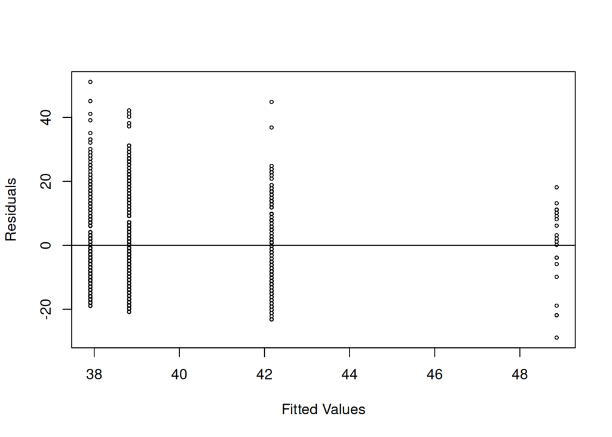

```r
# Residual plot
plot(age.model$fitted.values,age.model$residuals,
     xlab="Fitted Values",ylab="Residuals",cex=.5)
abline(h=0)
```

Notice that there are only 4 fitted (or predicted) values, because (again) the ANOVA model says that an individual’s measurement $X_{ij}$ is predicted by the mean of the group $\overline{X}_j$ to which that individual belongs: $\hat{X}_{ij} = \overline{X}_j$. The horizontal line is placed at a residual value of 0.

Things to look for in a residual plot are:

1. Symmetry about 0. Errors are normally distributed with mean 0. If the residuals are asymmetric around 0, there is a failure of the normality assumption. If the residuals for each group are not centered at 0 then there is structure in the data that has not been captured by the ANOVA model.
2. Approximately equal ranges in residuals across groups. If the ranges are evidently different, variance within each group differs across the groups and homoskedasticity is violated.
3. Outliers. Outliers and influential values in the raw data will appear as outliers in the residuals because the model will have difficulty predicting them well.

These features of a residual plot are indirect evidence of violations of assumptions. We can be more precise with QQ plots and statistical tests of homoskedasticity.

### QQ plots

Remember that a QQ plot plots theoretical quantiles from a specified distribution against the quantiles of the data. If a normal distribution is a good fit to the data then the QQ plot will show a nice straight line through the plotted points.

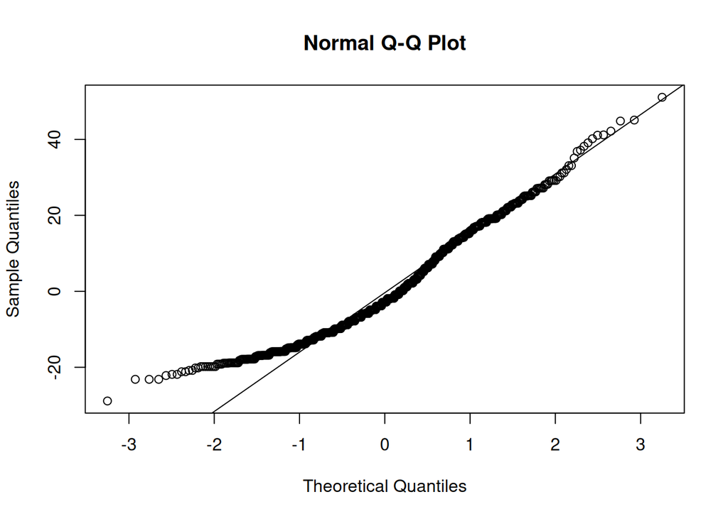

```r
# QQ plot of residuals
qqnorm(age.model$residuals)
# Add a best-fitting line
qqline(age.model$residuals)
```

The plot shows a good fit to the normal distribution everywhere except in the lower quantiles of residuals. We can get even more precise by doing a *Shapiro-Wilk test* of normality. This test focuses specifically on the deviations from the line shown in the QQ plot.

```r
shapiro.test(age.model$residuals)
```

```
##
##  Shapiro-Wilk normality test
##
## data:  age.model$residuals
## W = 0.95493, p-value = 1.022e-15
```

The $p$-value of the Shapiro-Wilk test statistic ($W$) is less that $\alpha=0.05$, so we reject the null hypothesis that the residuals are normally distributed. However, the Shapiro-Wilk test is very sensitive for large sample sizes like the GSS dataset, so the deviation from normality, while significant, may not be interesting.

### Levene’s Test of Equality of Variances

It is not clear from the residual plot if the homoskedasticity assumption is violated. The ranges are different across the groups but it can’t be determined just by looking if these differences are due to sampling error. To investigate this more closely, you can perform a Levene’s test. This test is robust to violations of the normality assumption, which is something that we now need to be sensitive to.

```r
# Levene's test for homogeneity of variance (in car library)
library(car)
leveneTest(age.model)
```

|  | Df | F value | Pr(>F) |
| --- | --- | --- | --- |
| group | 3 | 1.020296 | 0.3828798 |
|  | 869 | NA | NA |

The $p$-value for the Levene’s test is greater than $\alpha=0.05$, suggesting that we can’t reject the null hypothesis of homoskedasticity. So this assumption appears to hold for our data.

### 6. Your turn!

Perform a residual analysis of the ANOVA model fit to your data. Construct the residual and QQ plots and analyze them “by eye.” Using Shapiro-Wilks and Levene’s tests, determine the extent to which the ANOVA assumptions hold in your data.

```r
# Insert your code here
```

# Power and Effect Size

Power analysis and effect size calculations are important for understanding the practical significance of ANOVA results. In contrast to comparisons between two means, effect size measures for ANOVA often focus on the proportion of variance explained by the independent variable.

## Effect Sizes

Like for the $t$-test, when the null hypothesis is false the $F$-ratio is not distributed as an $F$. Instead, again like the $t$ statistic, it follows a non-central $F$ distribution. So the issue of effect sizes is often cast in terms of a noncentrality parameter. If the central $F$ has parameters $\nu$ and $\delta$, the numerator and denominator degrees of freedom, the non-central $F$ has parameters $\nu$, $\delta$, and $\lambda$, where $\lambda$ is the noncentrality parameter. We’ll return to the computation of $\lambda$ in a moment.

There are three common effect size measures for ANOVA: eta-squared ($\eta^2$), omega-squared ($\omega^2$) and Cohen’s $f^2$. In contrast to the $d$ (distance) measures of effect size we used for t-tests, these are called $r$ (correlation) measures.

Eta-squared is calculated as
$$\eta^2 =
\dfrac{SS_{\text{Between}}}{SS_{\text{Total}}}.$$
It represents the proportion of total variance in the dependent variable that is explained by the ANOVA model. (This is the same as the $r^2$ measure used in simple regression.)

While simple, unfortunately $\eta^2$ is a biased estimate of the effect size: it tends to overestimate the proportion of variance explained, especially for small sample sizes. Omega-squared is a less biased estimate of effect size and is calculated as
$$\omega^2 = \dfrac{SS_{\text{Between}} - (J -
1)MS_{\text{Within}}}{SS_{\text{Total}} +
MS_{\text{Within}}}.$$

Cohen’s $f^2$ is a transformation of $\eta^2$:
$$f^2 = \dfrac{\eta^2}{1 - \eta^2},$$
and when we talk about an effect size in ANOVA we usual mean Cohen’s $f$, which is just
$$f = \sqrt{\dfrac{\eta^2}{1 - \eta^2}}.$$

The noncentrality parameter $\lambda$ for the non-central $F$ distribution is a function of Cohen’s $f^2$:
$$\lambda = f^2 \sum_{j=1}^k N_j.$$

These are a lot of little formulas, and I present them so you know how to use them in `R` and to compute power using different functions in `R`.

Like the Cohen’s $d$ we encountered in tests of two means, there are guidelines for what we consider to be small, medium, or large effect sizes for $\eta^2$, $\omega^2$ and $f^2$:

| Size | $\eta^2,\omega^2$ |  | f |
| --- | --- | --- | --- |
| —————- | ——————— |  | —— |
| Small effect | 0.01 |  | 0.10 |
| Medium effect | 0.06 |  | 0.25 |
| Large effect | 0.14 |  | 0.40 |
| —————- | ——————— |  | —— |

These effects are easy to compute using commands from `R`’s `effectsize` package. Here is some code to compute $\eta^2$, $\omega^2$ and Cohen’s $f$.

```r
# Calculate effect size
eta.2 <- eta_squared(age.model)$Eta2
```

```
## For one-way between subjects designs, partial eta squared is equivalent
##   to eta squared. Returning eta squared.
```

```r
omega.2 <- omega_squared(age.model)$Omega2
```

```
## For one-way between subjects designs, partial omega squared is
##   equivalent to omega squared. Returning omega squared.
```

```r
cohens.f <- cohens_f(age.model)$Cohens_f
```

```
## For one-way between subjects designs, partial eta squared is equivalent
##   to eta squared. Returning eta squared.
```

The `effectsize` library has a bunch of random functions that you might find useful. We can convert $\eta^2$ to $f^2$ using the `eta2_to_f2` function.

```r
f.2 <- eta2_to_f2(eta.2)
f <- eta2_to_f(eta.2) # A fancy sqrt function

# Check:
cat("eta^2 = ",eta.2,", omega^2 = ",omega.2," Cohen's f = ",cohens.f)
```

```
## eta^2 =  0.0222341 , omega^2 =  0.01883742  Cohen's f =  0.1507969
```

```r
cat("\nf^2 = ",f.2," f = ",f) # returned by functions
```

```
##
## f^2 =  0.0227397  f =  0.1507969
```

```r
cat("\nf^2 = ",eta.2/(1-eta.2)," f = ",sqrt(f.2)) # check by hand
```

```
##
## f^2 =  0.0227397  f =  0.1507969
```

Both $\eta^2$ and $\omega^2$ indicate that reported health explains a small proportion of the variance in age. Cohen’s $f$ also suggests a small effect size.

### 7. Your turn!

Using your own dataset, compute the effect sizes $\eta^2$, $\omega^2$ and Cohen’s $f$ for your fitted ANOVA model. Interpret the results.

```r
# Insert your code here
```

## Power Analysis

We’ve been using the `pwrss` package for power analysis with $t$-tests. It also provides functions for power analysis with ANOVA. For diversity, and because the anova power computations are a bit easier, we’ll use the `pwr` package for power analysis with ANOVAs.

To compute sample size for a given level of power we need the desired effect size, significance level, and the information necessary to compute degrees of freedom ($J-1$).

```r
# Power analysis for one-way ANOVA of age~health data
# Desired power
one.minus.beta <- 0.80

# (Desired) effect size (Cohen's f)
cohens.f <- 0.25 # medium

pwr.anova.test(k = 4, f = cohens.f, sig.level = 0.05,
               power = one.minus.beta)
```

```
##
##      Balanced one-way analysis of variance power calculation
##
##               k = 4
##               n = 44.59927
##               f = 0.25
##       sig.level = 0.05
##           power = 0.8
##
## NOTE: n is number in each group
```

This output indicates that to detect a medium effect size ($f = 0.25$) with 80% power at $\alpha = 0.05$ with 4 groups, we need a total sample size of 180 respondents (45 per group $\times$ 4).

The `pwrss` package can perform a similar computation with the command `power.f.ancova`, but rather than Cohen’s $f$ it requires $\eta^2$. An ANCOVA is a generalization of an ANOVA model in which predictor variables (like health) can be both categorical and numeric. Here is code equivalent to that for `pwr.anova.test` using `power.f.ancova`.

```r
# Convert f=0.25 to eta^2
new.eta2 <- f2_to_eta2(0.25^2)
# new.eta2 <- 0.25^2/(1 + 0.25^2) # by hand

# Compute sample size for ANOVA with 4 groups and desired power 0.80
power.f.ancova(new.eta2,factor.levels=4,power=.8,alpha=.05)
```

```
## +--------------------------------------------------+
## |             SAMPLE SIZE CALCULATION              |
## +--------------------------------------------------+
##
## One-way Analysis of Variance (F-Test)
##
## ---------------------------------------------------
## Hypotheses
## ---------------------------------------------------
##   H0 (Null Claim) : eta.squared = 0
##   H1 (Alt. Claim) : eta.squared > 0
##
## ---------------------------------------------------
## Results
## ---------------------------------------------------
##   Total Sample Size      = 180  <<
##   Type 1 Error (alpha)   = 0.050
##   Type 2 Error (beta)    = 0.196
##   Statistical Power      = 0.804
```

The `power.f.ancova` function returns a necessary total sample size of 180. It is assumed (and desirable) that the 4 group sizes be as equal as possible: 180/4 = 45, exactly the number returned by the `pwr.anova.test` function.

### 8. Your turn!

Compute the post-hoc power of the ANOVA you performed on your own data. Compute Cohen’s $f$ directly or use a combination of the `eta_squared` and `eta2_to_f` functions from the `effectsize` package. Then use the `pwr.anova.test` function to compute the power of your ANOVA given your sample size, number of groups, and effect size.

```r
# Insert your code here
```

# Mean Contrasts

Go back to the issue of determining *why* an omnibus $F$-test is significant: which mean or means are different from the rest? There are two ways to handle this. One way is reflective of the “controversy” over performing one vs. two-tailed tests. You really should have some idea going into a study how things should turn out. Similarly, you should have some inkling of which conditions should show significant effects.

1. You’re clueless: An omnibus $F$ is significant but you don’t know why. In this situation, you will perform *post-hoc* tests of means to figure out which means are different. If the omnibus $F$ is not significant, *You. Can. Not. Perform. Post. Hoc. Tests!*
2. You know which groups should differ from the others, because you are smart, you’re an expert, and you gave your experiment lots of thought before you collected the data. In this situation you will perform *planned contrasts* and you will not conduct an omnibus $F$ test at all.

Here’s some new vocabulary: A difference between means or combination of means is called a *contrast*.

## Post-hoc tests

Post hoc tests identify specific group differences if the ANOVA is significant. There are lots of options, each with different strengths and weaknesses:

1. The Bonferroni and Dunn-Šidák procedures
2. Newman-Keuls test
3. Scheffé test
4. Tukey’s HSD test
5. Duncan’s multiple range test

We won’t discuss them all.

### Bonferroni and Dunn-Šidák

Remember that if we have $J$ groups then, if we want to test all pairs of means, we will need to perform $M = \binom{J}{2} = J(J-1)/2$ $t$-tests. If we use something like $\alpha_{PC}=0.05$, where $PC$ indicates “per comparison,” then the probability of making at least one Type I error will be $\alpha_{FW} = 1 - (1 - \alpha_{PC})^M$, which will be larger than $\alpha_{PC}$ for all $M>1$. We call $\alpha_{FW}$ the *family-wise error rate*. Both the Dunn-Šidák and Bonferroni procedures “correct” $\alpha_{PC}$ to insure that $\alpha_{FW}$ is no greater than some desired value (like 0.05).

The Dunn-Šidák correction simply inverts the equation for $\alpha_{FW}$:
$$\begin{eqnarray*}
\alpha_{FW} & = & 1 - (1 - \alpha_{PC})^M \\
& \rightarrow & (1 - \alpha_{FW}) = (1 - \alpha_{PC})^M \\
& \rightarrow & 1 - \alpha_{PC} = (1 - \alpha_{FW})^{1/M} \\
& \rightarrow & \alpha_{PC} = 1 - (1 - \alpha_{FW})^{1/M}.
\end{eqnarray*}$$

So if $J = 4$ and our desired $\alpha_{FW} = 0.05$, then $M=6$ and
$$\alpha_{PC} = 1 - (1 - 0.05)^{1/6} = 0.0085.$$
If we do each of our 6 tests and reject the 6 $H_0s$ only when the $p$-value is less than $\alpha_{PC} = 0.0085$ then our probability of making one or more Type I errors will be equal to $\alpha_{FW} = 0.05$

To control the family-wise error rate at level $\alpha$ we can also use the less-precise but easier Bonferroni correction, which sets the per-comparison $\alpha_{PC} = \alpha_{FW}/M$, where $M$ is still the number of comparisons to be made. If again we want $\alpha_{FW} \le 0.05$ and $M=6$, then $\alpha_{PC} = 0.05/6 = 0.0083$. This value is slightly lower than the Dunn-Šidák correction, which means that the Bonferroni procedure is more conservative than the Dunn-Šidák procedure: it will be slightly harder to reject the $H_0s$ using Bonferroni but the per-comparison $\alpha$-level is easier to compute.

One important thing to know about pairwise $t$-tests is how the standard error of the mean difference is computed. Remember for independent t-tests this is
$$s_{\overline{X} - \overline{Y}} = s_P \sqrt{\dfrac{1}{N_X} +
\dfrac{1}{N_Y}}$$
and
$$s_P^2 = \dfrac{(N_X-1) s_X^2 + (N_Y-1) s_Y^2}{N_X + N_Y - 2}.$$

For the pairwise $t$-tests across more than 2 groups, we will also use a pooled variance estimate, which we can do because of the homoskedasticity assumption of the ANOVA model. But now
$$s_P^2 = \dfrac{\sum_{i=1}^J (N_i-1) s_i^2}{N_{\text{Total}} - J},$$
which is the same thing as $MS_{Within}$. So the standard error of the mean difference for a pair or means $\overline{X}_i - \overline{X}_j$ *following a significant omnibus* $F$ is
$$s_{\overline{X}_i - \overline{X}_j} = \sqrt{MS_{Within}}
\sqrt{\dfrac{1}{N_i} + \dfrac{1}{N_j}}.$$

You could, of course, do all these $t$-tests one-by-one by hand. However, `R` has a tool to perform pairwise t-tests. The command is `pairwise.t.test`.

```r
# Compute the per-comparison alpha levels for alpha
# J <- length(unique(health))
M <- choose(J,2) # number of pairs
alpha <- 0.05

# Bonferroni PC error rate
Bonferroni <- alpha / M

# Dunn-Sidak PC error rate
Dunn.Sidak <- 1 - (1 - alpha)^(1/M)
cat("Bonferroni = ",Bonferroni," Dunn-Sidak = ",Dunn.Sidak)
```

```
## Bonferroni =  0.008333333  Dunn-Sidak =  0.008512445
```

```r
# Perform all M pairwise tests
pairwise.t.test(x=age,g=health,p.adjust.method="none")
```

```
##
##  Pairwise comparisons using t tests with pooled SD
##
## data:  age and health
##
##   1       2       3
## 2 0.38201 -       -
## 3 0.00311 0.01647 -
## 4 0.00036 0.00099 0.03636
##
## P value adjustment method: none
```

The `pairwise.t.test` function has a method to adjust $p$-values according to the desired correction factor. This method is specified by the `p.adjust.method` option. If you set `p.adjust.method="bonferroni"`, for example, it will multiply the $t$-test $p$-values by the value of $M$, allowing a comparison between the adjusted $p$-values and the desired familywise alpha level $\alpha_{FW}$ instead of the per-comparison alpha level $\alpha_{PC}$. I find this extraordinarily confusing so I set the $p$-value adjustment to “none.” Keep in mind that there are a large number of possible correction procedures (we have only looked at the two most common), and so if you find yourself using one we haven’t talked about this option might be useful.

Returning to the output, you can see that we can reject the null hypothesis $H_0:~\mu_i = \mu_j$ for three comparisons: health=1 vs. health=3 and 4, and health=2 vs. health=4. There seems to be no significant difference between the two best levels of health (health=1 and 2), the two poorest levels of health (health=3 and 4), or between health=2 and health=3.

There are some drawbacks to these two correction procedures. The primary drawback is that they are extraordinarily conservative. The per-comparison error rate can be orders of magnitude smaller than the desired familywise error rate, making it very difficult to reject $H_0$ (and hence greatly reducing power). The use of the pooled error variance estimate also means that the comparisons may not be independent, which is an assumption made by both correction methods – remember that computing $\alpha_{FW} = 1 - (1 - \alpha_{PC})^M$ assumes independence of the $M$ tests because we’re multiplying the probabilities of *not* making a Type I error on each test together.

For these reasons, alternatives to these correction factors are numerous and alternatives to pairwise $t$-tests have been developed. Some of these are listed above. For this notebook we will focus on the popular Tukey’s Honestly Significant Difference test.

### The Honestly Significant Difference

Tukey defined an “honestly significant difference” (HSD) as a single number to which all mean differences could be compared simultaneously. Among post-hoc tests, it provides the best balance of power and control of the Type I error rate.

The HSD test is based on the *Studentized range statistic* $q$, which is defined as
$$q = \dfrac{\overline{X}_{\max} -
\overline{X}_{\min}}{\sqrt{MS_{\text{Within}}/n}},$$
where the data ($X$) are drawn from a normal distribution, $\overline{X}_{\max}$ and $\overline{X}_{\min}$ are the largest and smallest group means, respectively, and $n = N_j, j=1,2,\ldots, J$ is the number of observations per group (assuming equal group sizes). The statistic $q$ follows a Studentized range distribution with parameters $J$ (the number of groups) and $\nu = N_{\text{Total}}-J$ (the degrees of freedom for $MS_{\text{Within}}$).

The distribution of $q$ has root `tukey` in R, but the density function `dtukey` is not defined because it has no closed form. Only the quantile and probability functions `qtukey` and `ptukey` are defined. There is a plot of 4 Studentized range distributions (for $k=3,6$ and $n=4,15$) in the lecture notes. A simulation of the $J=6,~n=15$ case is given in this code chunk. You can play around with $J$ and $n$ to see how these affect the shape of the distribution.

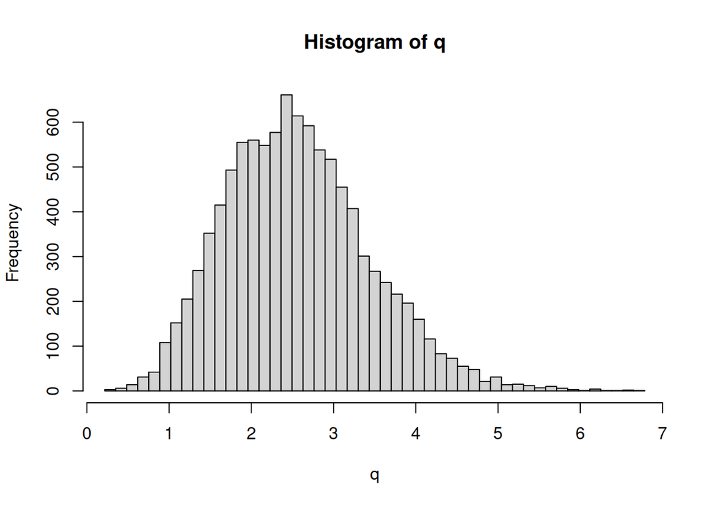

```r
# Simulate the Studentized range distribution for 4 sets of parameters
J <- 6 # number of groups
n <- 15 # group sizes

q <- replicate(10000,{
  # Simulate a dataset
  data <- data.frame(X=rnorm(J*n),group=rep(1:J,each=n))
  # Compute the pooled variance (MS_Within)
  sp2 <- mean(aggregate(data$X,by=list(data$group),var)$x)
  # Compute the values of q
  means <- aggregate(data$X,by=list(data$group),mean)$x
  (max(means)-min(means))/sqrt(sp2/n)
})
hist(q,breaks=seq(min(q)-.1,max(q)+.1,length=50))
```

Now we need to turn the statistic $q$ into an “honestly significant” mean difference HSD. We do this by first finding the critical value of $q$ that cuts off our desired $\alpha$ in the upper tail. This is done with the `qtukey` function. If $J=6$ and $n=15$, this value would be denoted as $q(1-\alpha,J,\nu = nJ - J)$. (Remember that $\nu$ is the number of degrees of freedom associated with $MS_{\text{Within}}$.)

```r
J <- 6
n <- 15
alpha <- 0.05
qtukey(1-alpha,J,J*n-J)
```

```
## [1] 4.124617
```

The HSD is the (absolute) mean difference $\left| \overline{X}_{\max} - \overline{X}_{\min} \right|$ that makes the $q$ statistic greater than the critical value $q(1-\alpha,J,\nu)$. Rearrange the equation for $q$ to solve for the significant mean difference:
$$\begin{eqnarray*}
q(1-\alpha,J,\nu) & = & HSD/\sqrt{MS_{\text{Within}}/n} \\
& \rightarrow & HSD =
q(1-\alpha,J,\nu)\sqrt{MS_{\text{Within}}/n}.
\end{eqnarray*}$$

#### Unequal Sample Sizes

An important thing to note is that up to now we have assumed equal group sizes $n$. If group sizes are unequal we need to figure out what to do with all the $N_js$. There’s a few acceptable strategies for dealing with this, and one is to use the *harmonic mean* of the group sizes. Another is to compute $n = 2 N_{\max} N_{\min}/(N_{\max} + N_{\min})$, where $N_{\min}$ and $N_{\max}$ are the sizes of the groups with the largest and smallest means.

What `R` does, by contrast, is called the *Tukey-Kramer method*. Think back to the Welch’s $t$-test, which is the test we used when we couldn’t assume homoskedasticity. For the Welch’s test, we estimated the standard error of $\overline{X}_1- \overline{X}_2$ as $\sqrt{\dfrac{s_1^2}{N_1} + \dfrac{s_2^2}{N_2}}$. The Tukey-Kramer method uses the same idea, estimating the standard error of $\overline{X}_i - \overline{X}_j$ as $SE_{ij} = \sqrt{\dfrac{1}{2} \left(\dfrac{MS_{\text{Within}}}{N_i} + \dfrac{MS_{\text{Within}}}{N_j}\right)}$. Thus the HSD will be slightly different for each difference, equal to $q_{ij}(1 - \alpha,J,\nu) SE_{ij}$.

We’ll finish this section by performing Tukey’s HSD analysis with the Tukey-Kramer method, using R’s `TukeyHSD` function.

```r
tukey.results <- TukeyHSD(age.model)
cat("\n--- Tukey's Honestly Significant Difference (HSD) Results ---\n")
```

```
##
## --- Tukey's Honestly Significant Difference (HSD) Results ---
```

```r
print(tukey.results)
```

```
##   Tukey multiple comparisons of means
##     95% family-wise confidence level
##
## Fit: aov(formula = age ~ health, data = data)
##
## $health
##           diff       lwr       upr     p adj
## 2-1  0.9109091 -1.769810  3.591628 0.8180000
## 3-1  4.2575758  0.561693  7.953459 0.0163883
## 4-1 10.9545455  3.082588 18.826503 0.0020371
## 3-2  3.3466667 -0.238019  6.931352 0.0772231
## 4-2 10.0436364  2.223270 17.864003 0.0054375
## 4-3  6.6969697 -1.526863 14.920803 0.1551389
```

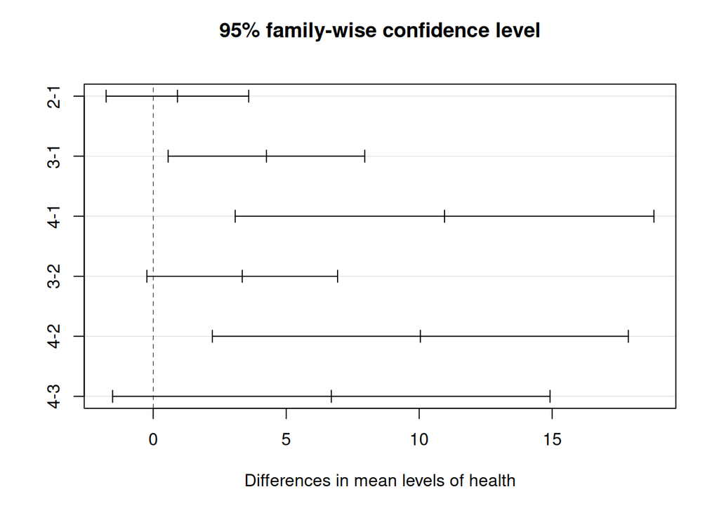

```r
plot(tukey.results)
```

This analysis shows significant differences between health=1 and health=3 and 4, and health=2 and health=4: the absolute values of these mean differences exceeds the HSD. `TukeyHSD` also provides a plot, if requested, of each observed value of $q$ centered within its 95% confidence interval. If the plotted interval does not include 0 (the dotted vertical line), then the mean difference is significant at the $\alpha = 0.05$ level.

### 9. Your turn!

Perform a post-hoc analysis of the ANOVA model you fit to your own data. Use the `pairwise.t.test` and `TukeyHSD` functions. If your omnibus $F$ was not significant, were any of the mean differences significant? Discuss what will happen to the Type I error rate if you do post hoc tests after failing to reject the omnibus hypothesis of all means being equal?

```r
# Insert your code here
```

## Planned Contrasts

A contrast is a linear combination of group means used to test a specific hypothesis about those means. It allows you to focus the test on a theoretically interesting difference, rather than just every possible pairwise difference. It is the going into an analysis with an idea of what you want to find that allows you to bypass the omnibus $F$ test entirely.

We use the notation $\Psi = c_1 \mu_1 + c_2 \mu_2 + \cdots + c_J \mu_J$ to define a contrast with the goal of testing the null hypothesis $H_0:~\Psi = 0$. The contrast coefficients $c_1, c_2, \ldots, c_J$ must sum to 0. The pairwise $t$-tests we did for post hoc tests are defined by one $c_i=1$, another $c_j=-1$ and all the other $c_ks=0$. For example, we showed that the mean age for health=1 and health=3 were significantly different. This contrast is defined by the coefficient vector $(1,0,-1,0)$, or $\Psi = (1) \mu_1 + (0) \mu_2 + (-1) \mu_3 + (0) \mu_4 = \mu_1 - \mu_3$.

My hypothesis is that people who report better levels of reported health (health=1 and 2) are younger than those who report poorer levels of reported health (health=3 and 4), because aging generally has negative impacts on overall health. I planned to test this hypothesis in advance of collecting the data, and the contrast that describes this pattern of results is defined by the coefficient vector $c(1/2,1/2,-1/2,-1/2)$. Note that you have some flexibility in selecting the values of the coefficients. They should appropriately weight the means to reflect the hypotheses of interest. It is common practice to select them so that the absolute value sums to 2, consistent with $\Psi$ representing a difference between two averaged groups.

The coefficient vector $c(1/2,1/2,-1/2,-1/2)$ defines the contrast $\Psi = (1/2)\mu_1 + (1/2)\mu_2 - (1/2) \mu_3 - (1/2)\mu_4 = \dfrac{\mu_1 + \mu_2}{2} - \dfrac{\mu_3 + \mu_4}{2}$: if $\Psi = 0$ then the mean of the two best health groups is equal to the mean of the two poorest health groups.

But how do we test $H_0:~\Psi = 0$? Turns out that’s pretty simple. First we compute the observed value of the contrast, which is
$$\hat{\Psi} = \sum_{j=1}^J c_j \overline{X}_j.$$
Then we need to compute the sum of squares for the contrast $\Psi$, which should equal $MS_{\text{Within}}$ approximately if $\Psi=0$. The sum of squares for $\Psi$ is given by $SS_{\Psi} = \hat{\Psi^2}/w$, where $w = \sum_{j=1}^J c_j^2/N_j$. This sum of squares has only 1 degree of freedom, so $MS_{\Psi} = SS_{\Psi}$.

Finally, we compute the $F$-ratio for the contrast as $MS_{\Psi}/MS_{\text{Within}}$, which follows an $F$ distribution with 1 numerator and $N_{\text{Total}}-J$ degrees of freedom.

Here’s how we do this in R. There’s a useful package, `multcomp`, that makes this easy. First we’ll do the computations by hand, then we’ll use the package.

```r
# Define the contrasts of interest
contrast.mx <- rbind(
  "Good health vs Poor health" = c(.5, .5, -.5, -.5),
  "Best health vs Rest" = c(1, -1/3, -1/3, -1/3)
)
# Group means and group sizes were computed earlier
# group.means <- aggregate(age,by=list(health),mean)$x
# N.groups <- as.numeric(table(health))

# Pull out MS_Within from the ANOVA summary
MS.Within <- summary(age.model)[[1]][["Mean Sq"]][2]

# Compute the p-value of the first contrast by hand
Psi.hat <- contrast.mx %*% group.means
w <- rowSums(contrast.mx^2 / rbind(N.groups,N.groups))
SS.Psi <- (Psi.hat)^2 / w
MS.Psi <- SS.Psi # 1 df
F.value <- MS.Psi / MS.Within
p.value <- 1 - pf(F.value,1,sum(N.groups)-length(N.groups))
data.frame(Psi.hat,MS.Psi,F.value,p.value)
```

|  | Psi.hat | MS.Psi | F.value | p.value |
| --- | --- | --- | --- | --- |
| Good health vs Poor health | -7.150606 | 3486.309 | 18.11180 | 2.309517e-05 |
| Best health vs Rest | -5.374343 | 3104.148 | 16.12642 | 6.437329e-05 |

Now use the multcomp package to do the contrasts.

```r
library(multcomp)
# Use the glht and mcp functions to compute contrasts
age.glht <- glht(age.model,linfct=mcp(health=contrast.mx))
summary(age.glht,test=adjusted("none"))
```

```
##
##   Simultaneous Tests for General Linear Hypotheses
##
## Multiple Comparisons of Means: User-defined Contrasts
##
##
## Fit: aov(formula = age ~ health, data = data)
##
## Linear Hypotheses:
##                                 Estimate Std. Error t value Pr(>|t|)
## Good health vs Poor health == 0   -7.151      1.680  -4.256 2.31e-05 ***
## Best health vs Rest == 0          -5.374      1.338  -4.016 6.44e-05 ***
## ---
## Signif. codes:  0 '***' 0.001 '**' 0.01 '*' 0.05 '.' 0.1 ' ' 1
## (Adjusted p values reported -- none method)
```

The output from the glht function looks a little different from what we computed by hand. There are several reasons for this, but be reassured that the two analyses are equivalent.

First, the glht function computes t-values rather than F-values. This is okay, because we know that a squared $t$ with $J$ degrees of freedom is equal to an $F$ with 1 and $J$ degrees of freedom. You can verify that the $t$-statistics output by glht are equal to the square roots of the $F$-values we computed by hand.

```r
# Verify that t^2 = F
cat("From the glht function:\n")
```

```
## From the glht function:
```

```r
summary(age.glht)$test$tstat^2
```

```
## Good health vs Poor health        Best health vs Rest
##                   18.11180                   16.12642
```

```r
cat("\nFrom our by-hand calculations:\n")
```

```
##
## From our by-hand calculations:
```

```r
F.value
```

```
##                                [,1]
## Good health vs Poor health 18.11180
## Best health vs Rest        16.12642
```

```r
# Verify that MS.Within = SE.Psi^2 / w and that SE.Psi = sqrt(MS.Within * w)
# Standard errors from the glht output
SE.Psi.glht <-summary(age.glht)$test$sigma
SE.Psi.glht
```

```
## Good health vs Poor health        Best health vs Rest
##                   1.680204                   1.338309
```

```r
# Compute the standard errors from the MS.Within and the w we computed by hand
sqrt(MS.Within * w)
```

```
## Good health vs Poor health        Best health vs Rest
##                   1.680204                   1.338309
```

```r
# Compute MS.Within from the standard errors in the glht output
SE.Psi.glht^2 / w
```

```
## Good health vs Poor health        Best health vs Rest
##                   192.4883                   192.4883
```

```r
MS.Within
```

```
## [1] 192.4883
```

Finally, note that the p-values output by glht are the same as those we computed by hand.

```r
# Verify that p-values are almost equal
cat("From the glht function:\n")
```

```
## From the glht function:
```

```r
summary(age.glht,test=adjusted("none"))$test$pvalues
```

```
## Good health vs Poor health        Best health vs Rest
##               2.309517e-05               6.437329e-05
```

```r
cat("\nFrom our by-hand calculations (times 2 for two-tailed):\n")
```

```
##
## From our by-hand calculations (times 2 for two-tailed):
```

```r
p.value
```

```
##                                    [,1]
## Good health vs Poor health 2.309517e-05
## Best health vs Rest        6.437329e-05
```

OK, but wait! Didn’t we just two two $t$-tests (and two $F$-tests)? Aren’t we supposed to adjust our alpha level if we do multiple tests? Yes, yes we are. The `glht` function makes this adjustment via that `test=adjusted()` option in the `summary` function. By saying “none” for this we forced `summary` not to adjust for multiple comparisons. By default `ghlt` uses the something called a “single-step method” (similar to the Bonferroni correction) to inflate the $p$-values and penalize us appropriately for multiple tests.

```r
summary(age.glht)
```

```
##
##   Simultaneous Tests for General Linear Hypotheses
##
## Multiple Comparisons of Means: User-defined Contrasts
##
##
## Fit: aov(formula = age ~ health, data = data)
##
## Linear Hypotheses:
##                                 Estimate Std. Error t value Pr(>|t|)
## Good health vs Poor health == 0   -7.151      1.680  -4.256 4.12e-05 ***
## Best health vs Rest == 0          -5.374      1.338  -4.016 0.000113 ***
## ---
## Signif. codes:  0 '***' 0.001 '**' 0.01 '*' 0.05 '.' 0.1 ' ' 1
## (Adjusted p values reported -- single-step method)
```

Compare these adjusted $p$-values to those we computed using the unadjusted method. Note that the $p$-values are larger now, approximately twice those of the unadjusted values, reflecting the penalty for multiple tests.

### 10. Your turn!

Perform planned contrasts on your own data. Define at least two contrasts that reflect interesting hypotheses about your data. Use either the by-hand method or the `glht` function from the `multcomp` package. Explain your results.

```r
# Insert your code here
```

## Orthogonal Contrasts

When you perform multiple planned contrasts, it is important to consider whether the contrasts are *orthogonal* or not. Orthogonal contrasts are statistically independent of one another, meaning that the outcome of one contrast does not influence the outcome of another. This independence is important because it allows for clearer interpretation of results and helps maintain the overall Type I error rate when multiple contrasts are tested.

Two contrasts defined by coefficient vectors $c^{(1)}$ and $c^{(2)}$ are orthogonal if
$$\sum_{j=1}^J N_j c_j^{(1)} c_j^{(2)} =
0.$$
If the group sizes are equal, this reduces to the simpler condition
$$\sum_{j=1}^J c_j^{(1)} c_j^{(2)}
= 0.$$

For example, consider the two contrasts we defined earlier for the health variable: 1. Good health vs Poor health: $c^{(1)} = (0.5, 0.5, -0.5, -0.5)$ 2. Best health vs Rest: $c^{(2)} = (1, -1/3, -1/3, -1/3)$ To check if these contrasts are orthogonal, we compute the sum of the products of their coefficients:
$$(0.5)(1) + (0.5)(-1/3) + (-0.5)(-1/3) + (-0.5)(-1/3) = 0.5 - 0.1667 +
0.1667 + 0.1667 = 0.6667 \neq 0.$$
(Weighting by sample sizes also results in a sum that is not equal to 0.) Because the sum is not zero, these contrasts are not orthogonal.

We talked about partitioning total variance in ANOVA. When contrasts are orthogonal, the sums of squares associated with each contrast adds up to the total sum of squares between groups. This means that each contrast explains a unique portion of the variance in the data, allowing for a clearer understanding of how different factors contribute to group differences.

When contrasts are not orthogonal, they do not cleanly partition the variance. Their variances overlap and the sum of squares for the contrasts will not add up to the total sum of squares between groups, making it harder to discern the unique contribution of each contrast.

When planning contrasts, it is often beneficial to design them to be orthogonal, especially when multiple contrasts are being tested. This helps ensure that each contrast provides distinct information about the group differences and maintains the integrity of statistical inferences. However, not all research questions can be addressed with orthogonal contrasts; sometimes non-orthogonal contrasts are necessary to test specific hypotheses.

```r
# Define orthogonal contrasts for 4 groups
poly.contrasts <- contr.poly(4)
helmert.contrasts <- contr.helmert(4)
print("Polynomial Contrasts:")
```

```
## [1] "Polynomial Contrasts:"
```

```r
print(poly.contrasts)
```

```
##              .L   .Q         .C
## [1,] -0.6708204  0.5 -0.2236068
## [2,] -0.2236068 -0.5  0.6708204
## [3,]  0.2236068 -0.5 -0.6708204
## [4,]  0.6708204  0.5  0.2236068
```

```r
print("Helmert Contrasts:")
```

```
## [1] "Helmert Contrasts:"
```

```r
print(helmert.contrasts)
```

```
##   [,1] [,2] [,3]
## 1   -1   -1   -1
## 2    1   -1   -1
## 3    0    2   -1
## 4    0    0    3
```

The `contrasts` function in `R` can be used to incorporate contrasts into an ANOVA. The `split` option in the `summary` function tells `R` to break down the sum of squares into components associated with each contrast.

```r
# Fit ANOVA model with polynomial contrasts
contrasts(health) <- poly.contrasts
age.poly.model <- aov(age ~ health)
summary(age.poly.model,
        split=list(health=list("Linear"=1,
                              "Quadratic"=2,
                              "Cubic"=3)))
```

```
##                      Df Sum Sq Mean Sq F value   Pr(>F)
## health                3   3804  1267.9   6.587  0.00021 ***
##   health: Linear      1   2959  2959.3  15.374 9.51e-05 ***
##   health: Quadratic   1    838   838.4   4.355  0.03718 *
##   health: Cubic       1      6     6.0   0.031  0.85984
## Residuals           869 167272   192.5
## ---
## Signif. codes:  0 '***' 0.001 '**' 0.01 '*' 0.05 '.' 0.1 ' ' 1
```

Setting $\alpha_{PC} = 0.05/3 = 0.0167$ to control the family-wise error rate at $\alpha_{FW} = 0.05$ for the three contrasts, we see that only the linear contrast is significant. This analysis suggest that the variance in age across health levels is primarily explained by a linear trend, with no significant quadratic or cubic components.

Note that the `split` option only works when the contrasts are orthogonal. If you try to use it with non-orthogonal contrasts or with unequal group sizes the values that `summary` returns will not be the same as those that you compute by hand. If you want to use non-orthogonal contrasts or have unequal group sizes, you should use the `glht` function from the `multcomp` package as we did earlier.

### 11. Challenge: Your turn!

Define at least two orthogonal contrasts for your own data. You can use polynomial, Helmert, or your own orthogonal contrasts. Perform the analysis using either the `split` option in the `summary` function or the `glht` function from the `multcomp` package. Explain your results.

```r
# Insert your code here
```

## Summary

Post hoc and planned contrasts allow you to test specific hypotheses about group means. Post hoc contrasts require a significant omnibus F test; planned contrasts do not require this.

Bonferroni and Dunn-Šidák corrections are simple ways to control the family-wise error rate $\alpha_{FW}$ when performing multiple post hoc tests, but they are conservative and reduce power. Tukey’s HSD test provides a better balance of power and Type I error control for post hoc tests and does not require adjustment to the per-comparison alpha level $\alpha_{PC}$.

Planned contrasts, although they do not require a significant omnibus F test, will require adjustments for multiple comparisons. Bonferroni or Dunn-Šidák corrections can be used here as well, but you might consider using the `glht` function from the `multcomp` package to do the heavy lifting.

The use of orthogonal contrasts and post hoc pairwise t-tests share the characteristic that neither approach is based on a theoretical understanding of the data. Orthogonal contrasts are statistically independent, but they may not reflect the hypotheses of interest. Pairwise $t$-tests examine all possible mean differences, but many of these may not be theoretically interesting. When possible, it is best to define planned contrasts that reflect your theoretical understanding of the data, and remember to adjust your $\alpha_{PC}$ level to maintain a low $\alpha_{FW}$ error rate.

# Factorial ANOVA

To this point we have been doing “one-way” ANOVAs with a single categorical independent variable. Now we’ll expand that to two. When we have observations in each combination of levels of two categorical independent variables, we call this a “two-way” or “factorial” ANOVA. Factorial ANOVAs allow us to examine not only the *main effects* of each independent variable on the dependent variable, but also whether there is an *interaction effect* between the two independent variables. We could have more than two independent variables, of course, but for now we’ll stick with two for simplicity. The principles we discuss here will generalize to more than two independent variables.

Let’s load up the data again and start from scratch.

```r
data <- read.csv("GSS_1980.csv",header=TRUE)
# Pull out variables of interest
happy <- data$HAPPY
age <- data$AGE
health <- data$HEALTH
```

For the functions we’ll use later, it’s important to have equal sample sizes, so we’ll first collapse health=3 and 4 into a single category (“not good”) and then pull out 25 observations from each combination of health and happy.

```r
# Collapse health=3 and 4 into a single category
health.sub <- health
health.sub[health==4] <- 3

# Change health and happy to factors
health.sub <- factor(health.sub)
happy.sub <- factor(happy)
```

Subset the data to ensure equal sample sizes in each combination of health and happy.

```r
set.seed(1234) # for reproducibility
# Pull 25 observations from each combination of health and happy and make a new dataset from them
data.sub <- data.frame()
# For each level of health
for (i in levels(health.sub)) {
  # and each level of happy
  for (j in levels(happy.sub)) {
    # extract all observations in the cell
    combo.obs <- which(health.sub == i & happy.sub == j)
    # and choose 25 of them at random.
    if (length(combo.obs) > 25) obs <- sample(combo.obs, 25,replace=FALSE)
    # Add them to the new data frame
    data.sub <- rbind(data.sub,
                      data.frame(health=rep(i,length(obs)),
                                 happy=rep(j,length(obs)),
                                 age=age[obs]))
  }
}
# Pull the variables out of the data frame so we don't have to type $ signs
age.sub <- data.sub$age
health.sub <- data.sub$health
happy.sub <- data.sub$happy
```

Take a quick look at the subsetted data.

```
## ──────────────────────────────────────────────────────────────────────────────
## Age by Health and Happiness
##
## Summary:
## n pairs: 225, valid: 225 (100.0%), missings: 0 (0.0%), groups: 3
##
##
##               1        2        3
## mean     38.573   38.960   42.533
## median   35.000   35.000   42.000
## sd       13.532   13.425   15.034
## IQR      22.000   22.500   24.000
## n            75       75       75
## np      33.333%  33.333%  33.333%
## NAs           0        0        0
## 0s            0        0        0
##
## Kruskal-Wallis rank sum test:
##   Kruskal-Wallis chi-squared = 2.9645, df = 2, p-value = 0.2271
```

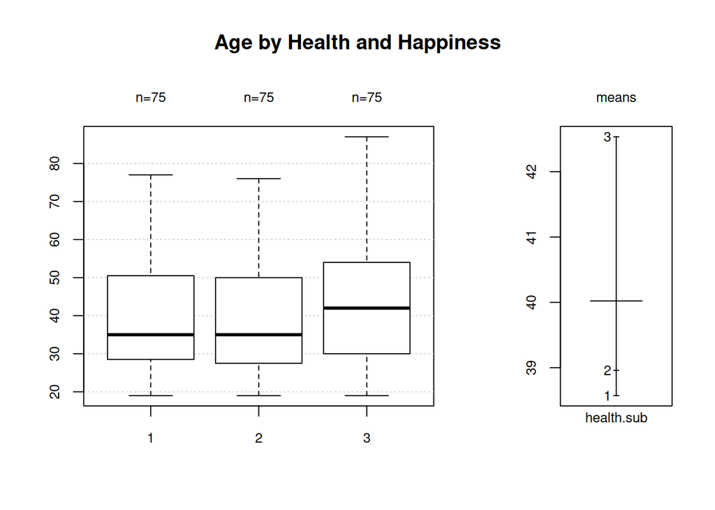

```
## ──────────────────────────────────────────────────────────────────────────────
## Age by Health and Happiness
##
## Summary:
## n pairs: 225, valid: 225 (100.0%), missings: 0 (0.0%), groups: 3
##
##
##               1        2        3
## mean     43.680   39.267   37.120
## median   41.000   36.000   34.000
## sd       15.321   12.510   13.606
## IQR      22.500   21.500   20.500
## n            75       75       75
## np      33.333%  33.333%  33.333%
## NAs           0        0        0
## 0s            0        0        0
##
## Kruskal-Wallis rank sum test:
##   Kruskal-Wallis chi-squared = 7.8169, df = 2, p-value = 0.02007
```

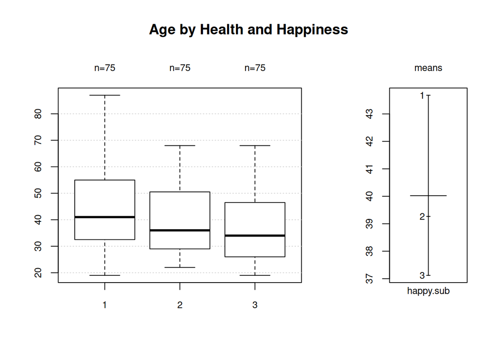

```r
# Make a box and whisker plot
Desc(age.sub ~ health.sub + happy.sub,
     main="Age by Health and Happiness",
     xlab="Health and Happiness Levels",
     ylab="Age")
```

The difference between a one-way and a two-way ANOVA is in how the sums of squares are partitioned. In a one-way ANOVA we partition the total sum of squares into between groups $SS_{\text{Between}}$ and within groups $SS_{\text{Within}}$ sums of squares. In a two-way ANOVA we partition the total sum of squares into three between groups sums of squares (one for each independent variable and one for the interaction between them) and the within groups sum of squares.

To partition the variance in this kind of design, consider first the contingency that counts the number of observations in each combination of the levels of each independent variable.

```r
table("J"=health.sub,"K"=happy.sub)
```

```
##    K
## J    1  2  3
##   1 25 25 25
##   2 25 25 25
##   3 25 25 25
```

I renamed the two independent variables $J$ and $K$ so that we can understand the notation a little better. I’m also going to let $J$ and $K$ represent the number of levels of each factor. It should be clear which I mean whenever I use it (and if it isn’t please let me know.)

Each frequency (25) of the pairs of levels of $J$ and $K$ in the table above represents a “cell” of the experiment. In this case there are $J=3$ levels of health and $K=3$ levels of happy, for a total of $J \times K = 9$ cells. Each cell has $N_{jk}$ observations, where $j=1,2,\ldots,J$ and $k=1,2,\ldots,K$. The total number of observations across all cells is $N_{\text{Total}} = \sum_{j=1}^J \sum_{k=1}^K N_{jk}$. An individual measurement in the $jk^{th}$ cell is denoted as $X_{ijk}$, where $i=1,2,\ldots,N_{jk}$ indexes the individual observations within that cell.

Now things will get a little strange but stick with me. We need to define several means to help us partition the variance. The grand mean of all observations across all cells is $\overline{\overline{X}} = \dfrac{1}{N_{\text{Total}}} \sum_{j=1}^J \sum_{k=1}^K \sum_{i=1}^{N_{jk}} X_{ijk}$. Note the addition of a new summation sign that corresponds to the sum over the second independent variable $K$.

We need to compute *marginal* sample sizes and means for each level of each factor. The notation will use a dot to indicate the factor over which the sample sizes and means are being taken. So, for example, the number of observations in level $j$ of variable $J$ will be written as $N_{j \cdot}$. The means of the observations at level $j$ of factor $J$ is $\overline{X}_{j\cdot} = \dfrac{1}{N_{j \cdot}} \sum_{k=1}^K \sum_{i=1}^{N_{jk}} X_{ijk}$. The mean of the observations at level $k$ of factor $K$ is similarly $\overline{X}_{\cdot k} = \dfrac{1}{N_{\dot k}} \sum_{j=1}^J \sum_{i=1}^{N_{jk}} X_{ijk}$.

Finally, we need the cell means. The mean of the observations in the $jk^{th}$ cell is $\overline{X}_{jk} = \dfrac{1}{N_{jk}} \sum_{i=1}^{N_{jk}} X_{ijk}$.

Consider again the total sum of squares $SS_{\text{Total}}$. We will compute this the same way as before:
$$SS_{\text{Total}} = \sum_{k=1}^K \sum_{j=1}^J \sum_{i=1}^{N_{jk}}
\left(X_{ijk} - \overline{\overline{X}} \right)^2$$
Note that this is just the numerator of $s^2_X$ without regard to any group structure.

```r
# Compute the grand mean and total variance
N.Total <- length(age.sub)
grand.mean <- mean(age.sub)
grand.var <- var(age.sub)

# Compute the total sum of squares
SS.Total <- sum((age.sub - grand.mean)^2)

cat("Grand Mean:", grand.mean, "\n")
```

```
## Grand Mean: 40.02222
```

```r
cat("Total Sum of Squares:", SS.Total, "\n")
```

```
## Total Sum of Squares: 44328.89
```

```r
# Notice that SS.Total = (N.Total - 1) * grand.var
cat("Verification:", (N.Total - 1) * grand.var, "\n")
```

```
## Verification: 44328.89
```

In one-way ANOVA we talked about $SS_{\text{Between}}$ and $SS_{\text{Within}}$. In two-way ANOVA the $SS_{\text{Between}}$ will be replaced with $SS_{\text{Cells}}$, which is computed in the same way:
$$SS_{\text{Cells}} = \sum_{k=1}^K \sum_{j=1}^J N_{jk} \left(
\overline{X}_{jk} - \overline{\overline{X}} \right)^2.$$

But now, we will partition the $SS_{\text{Cells}}$ into three components: the sum of squares $SS_J$ associated with factor $J$, the sum of squares $SS_K$ associated with factor $K$, and the sum of squares $SS_{JK}$ associated with the interaction between factors $J$ and $K$. These are computed as follows:
$$SS_J = \sum_{j=1}^J N_{j \cdot} \left( \overline{X}_{j \cdot} -
\overline{\overline{X}} \right)^2,$$
$$SS_K = \sum_{k=1}^K N_{\cdot k}
\left( \overline{X}_{\cdot k} - \overline{\overline{X}} \right)^2,$$
and then, because the interaction term is what’s left over after accounting for the main effects of $J$ and $K$,
$$SS_{J
\times K} = SS_{\text{Cells}} - (SS_J + SS_K).$$

The only thing we have to compute now is the within groups sum of squares, which can be computed by pooling the cell variances $s^2_{ij}$ the same way as before. However, knowing that $SS_{\text{Total}} + SS_{\text{Cells}} + SS_{\text{Within}}$,
$$SS_{\text{Within}} = SS_{\text{Total}} - SS_{\text{Cells}},$$
which is a bit easier.

Treat the age variable $X$ as a function of health $J$ and happiness $K$. We might expect to see age increase with increases in health (remember that health=1 is excellent health and health=4 is poor health). We might also expect to see differences in age with reported happiness (happy people might tend to be older because they are more stable, or unhappy people might tend to be older because of poor health or having lost friends and family). There might also be an *interaction* between health and happiness, such that the age difference between happy and less happy people might be less for unhealthy than for healthy people.

Let’s fit the ANOVA model and look for these sums of squares in the output. For the `aov` function, we specify two independent variables by expanding the model formula from `age.sub ~ health.sub` to `age.sub ~ health.sub + happy.sub + health.sub:happy.sub`, where happy is the second independent variable and `health.sub:happy.sub` indicates an interaction between health and happy. The `+` signs indicate that we are including main effects for both health and happy, while the `:` indicates that we are including an interaction effect between health and happy. An equivalent formula is `age.sub~health.sub*happy.sub`, which includes main effects and the interaction explicitly.

```r
# Fit the two-way ANOVA model
age.factorial.model <- aov(age.sub ~
                    happy.sub + health.sub +
                    health.sub:happy.sub)
summary(age.factorial.model)
```

```
##                       Df Sum Sq Mean Sq F value Pr(>F)
## happy.sub              2   1678   839.0   4.359 0.0139 *
## health.sub             2    715   357.5   1.857 0.1586
## happy.sub:health.sub   4    358    89.5   0.465 0.7616
## Residuals            216  41578   192.5
## ---
## Signif. codes:  0 '***' 0.001 '**' 0.01 '*' 0.05 '.' 0.1 ' ' 1
```

You can validate the degrees of freedom and sums of squares computed by `R` by computing them by hand. This chunk of code computes the degrees of freedom and sums of squares for the main effects, interaction, and error ($SS_{\text{Within}}$). For each main effect, if there are $J$ and $K$ levels of factors $J$ and $K$, respectively, then the degrees of freedom for each main effect is $df_J = J-1$ and $df_K = K-1$. The degrees of freedom for the interaction effect is $df_{J \times K} = (J-1)(K-1)$. The degrees of freedom for the within groups variance is $df_{\text{Within}} = N_{\text{Total}} - JK$; think about this one as you did for the one-way ANOVA where you subtracted off the number of levels, but now you’re subtracting off the number of cells. The sum of the main effects and interaction degrees of freedom should equal the total degrees of freedom between groups: $df_J + df_K + df_{J \times K} = JK - 1$.

```r
# Compute cell means
cell.means <- aggregate(age.sub, by=list(health.sub, happy.sub), mean)
colnames(cell.means) <- c("health", "happy", "mean")

# Compute marginal means
marginal.means.health <- aggregate(age.sub, by=list(health.sub), mean)
colnames(marginal.means.health) <- c("health", "mean")
marginal.means.happy <- aggregate(age.sub, by=list(happy.sub), mean)
colnames(marginal.means.happy) <- c("happy", "mean")

# Compute sample sizes
N.jk <- as.matrix(table(health.sub, happy.sub))
N.j.dot <- rowSums(N.jk)
N.dot.k <- colSums(N.jk)

# Compute the degrees of freedom
df.Health <- length(N.j.dot)-1 # J-1
df.Happy <- length(N.dot.k)-1 # K-1
df.HealthHappy <- df.Health*df.Happy # (J-1)(K-1)
df.Within <- N.Total - length(N.j.dot)*length(N.dot.k) # N.Total - JK

# Compute SS_Cells
SS.Cells <- sum(N.jk * (matrix(cell.means$mean,
                nrow=3, ncol=3) - grand.mean)^2)
# Compute SS_Health
SS.Health <- sum(N.j.dot * (marginal.means.health$mean - grand.mean)^2)
# Compute SS_Happy
SS.Happy <- sum(N.dot.k * (marginal.means.happy$mean - grand.mean)^2)
# Compute SS_Interaction
SS.Interaction <- SS.Cells - (SS.Health + SS.Happy)
# Compute SS_Within
SS.Within <- SS.Total - SS.Cells

# Display results so far
factorial.anova <- data.frame("Source" = c("Health","Happy","Health:Happy","Within"),
          "Df"=c(df.Health,df.Happy,df.HealthHappy,df.Within),
          "SS" = c(SS.Health,SS.Happy,SS.Interaction,SS.Within))
factorial.anova
```

| Source | Df | SS |
| --- | --- | --- |
| Health | 2 | 714.9956 |
| Happy | 2 | 1677.9822 |
| Health:Happy | 4 | 357.8311 |
| Within | 216 | 41578.0800 |

To complete the ANOVA table we need to compute the mean squares and F-ratios for each source of variance. The mean squares are computed as usual: $MS_{\text{Source}} = SS_{\text{Source}}/df$. The F-ratios are also computed as usual: $F = MS_{\text{Source}}/MS_{\text{Within}}$.

```r
# Compute the mean squares
MS.Health <- SS.Health / df.Health
MS.Happy <- SS.Happy / df.Happy
MS.Interaction <- SS.Interaction / df.HealthHappy
MS.Within <- SS.Within / df.Within
factorial.anova$MS <- c(MS.Health, MS.Happy, MS.Interaction, MS.Within)

# Compute the F ratios
F.Health <- MS.Health / MS.Within
F.Happy <- MS.Happy / MS.Within
F.Interaction <- MS.Interaction / MS.Within
factorial.anova$F <- c(F.Health, F.Happy, F.Interaction,NA)

# Compute the F p-values; note the degrees of freedom
p.Health <- 1 - pf(F.Health, df.Health, df.Within)
p.Happy <- 1 - pf(F.Happy, df.Happy, df.Within)
p.Interaction <- 1 - pf(F.Interaction, df.HealthHappy, df.Within)
factorial.anova$p.value <- c(p.Health, p.Happy, p.Interaction,NA)
factorial.anova
```

| Source | Df | SS | MS | F | p.value |
| --- | --- | --- | --- | --- | --- |
| Health | 2 | 714.9956 | 357.49778 | 1.8572171 | 0.1585906 |
| Happy | 2 | 1677.9822 | 838.99111 | 4.3585966 | 0.0139407 |
| Health:Happy | 4 | 357.8311 | 89.45778 | 0.4647372 | 0.7615733 |
| Within | 216 | 41578.0800 | 192.49111 | NA | NA |

Check now to see that the `factorial.anova` data frame gives the same values as the `summary` output.

### Unequal Sample Sizes

If the experiment is not balanced (equal sample sizes in each cell), because the `aov` function returns what is called “Type I” sums of squares, they will not be equal to the sums of squares you compute by hand. Furthermore, the sums of squares will change depending on the order of the variables in the formula passed to `aov`. This is because the sums of squares for each source can no longer be perfectly partitioned: there will be some influence of factor $J$ in the main effect of $K$ and vice versa.

Go back to the full GSS_1980 dataset. Fit the factorial ANOVA model in two ways, with health first and then with happy first.

```r
# Fit the two-way ANOVA model with health entered first
summary(aov(age~health+happy+health:happy))
```

```
##               Df Sum Sq Mean Sq F value   Pr(>F)
## health         1   2959  2959.3  15.507 8.88e-05 ***
## happy          1   2197  2197.2  11.514 0.000722 ***
## health:happy   1     82    81.9   0.429 0.512452
## Residuals    869 165838   190.8
## ---
## Signif. codes:  0 '***' 0.001 '**' 0.01 '*' 0.05 '.' 0.1 ' ' 1
```

```r
# Now put happy first
summary(aov(age~happy+health + health:happy))
```

```
##               Df Sum Sq Mean Sq F value  Pr(>F)
## happy          1   1250    1250   6.552  0.0106 *
## health         1   3906    3906  20.469 6.9e-06 ***
## happy:health   1     82      82   0.429  0.5125
## Residuals    869 165838     191
## ---
## Signif. codes:  0 '***' 0.001 '**' 0.01 '*' 0.05 '.' 0.1 ' ' 1
```

If you compute the sums of squares by hand you will see that the sums of squares for health equals the sums of squares computed by `aov` when health is first. The sums of squares for happy equals the sums of squares computed by `aov` when happy is first.

A detailed explanation for why this happens is beyond the scope of this notebook (but check [this](https://bookdown.org/ndphillips/YaRrr/type-i-type-ii-and-type-iii-anovas.html) link). Briefly, Type I sums of squares are computed by fitting different models sequentially, starting with the simplest and adding factors one by one. Type III sums of squares are computed by fitting all factors first and then removing them one at a time. There are also Type II and IV sums of squares. Each type of sums of squares has its uses, but Types II and III are generally preferred for unbalanced designs because the results are independent of the order in which the factors are specified in the model formula.

For unbalanced designs you can use the `Anova` function from the `car` package, which computes Type II and III sums of squares that are independent of the order in which the independent variables are specified in the model formula. I’ve always used Type III sums of squares, but the reason for this is [probably based mostly in tradition](https://seriousstats.wordpress.com/2020/05/13/type-ii-and-type-iii-sums-of-squares-what-should-i-choose/) and not any strong theoretical foundation.

```r
# Fit the two-way ANOVA model to the whole dataset using lm() and then Anova() from the car package
age.Anova <- lm(age~health+happy+happy:health)
Anova(age.Anova,type="III")
```

|  | Sum Sq | Df | F value | Pr(>F) |
| --- | --- | --- | --- | --- |
| (Intercept) | 24660.03591 | 1 | 129.2202800 | 5.166412e-28 |
| health | 142.95525 | 1 | 0.7490953 | 3.870017e-01 |
| happy | 748.65400 | 1 | 3.9229983 | 4.794481e-02 |
| health:happy | 81.94731 | 1 | 0.4294095 | 5.124523e-01 |
| Residuals | 165837.52337 | 869 | NA | NA |

Only the main effect of `happy` is significant at an $\alpha=0.05$ level. But wait…

### How Many Tests?

You probably wondered about doing three $F$-tests and the Type I error inflation problem we talked about earlier in the context of pairwise $t$-tests. Good for you!

Yes, [you should correct your alpha level to accommodate 3 tests](https://link.springer.com/article/10.3758/s13423-015-0913-5). Be aware that people will argue with you about this. The conservative and statistically “pure” approach would be to reduce the per-comparison alpha level according to something like the Bonferroni or Dunn-Šidák correction. Common practice, however, is to argue that the ANOVA model you just fit is a single test, the sums of squares are independent from each other (if the group sizes are equal), and performing a correction is “too conservative.”

If you use a Bonferroni correction for the alpha-level in the ANOVA you just performed, $\alpha_{PC} = 0.05/3 = 0.0167.$ In this case, there are no significant main effects of or interactions between health and happy on respondent age in the full data set. In the subsetted (balanced) dataset the main effect of happy is still significant after the correction.

### 12. Your turn!

Choose two independent variables and one dependent variable and plot the means of the dependent variable as a function of the values of the two independent variables.

1. What does the mean pattern look like? Are there any main effects? Is there an interaction?
2. Fit an ANOVA model predicting the dependent variable from the two independent variables and their interaction. Use `aov` (if there are roughly equal group sizes) or `Anova` if the groups are unequal. Describe your results and provide an interpretation. Are the significant (and insignificant) effects consistent with what you saw in your plots?

```r
# Insert your code here
```

# Repeated Measures ANOVA

Repeated measures ANOVA is used when the same subjects are measured under different conditions or at different time points. This design accounts for the correlation between measurements taken from the same subject, which can increase statistical power.

For this section we’ll use some (simulated) recognition memory data. Five participants are given 3 lists of 40 words each to memorize. Depending on the list, they are limited to 500ms, 1000ms, or 1500ms per word. At test, the words just studied are mixed with 40 new words and shown to the participants one at a time. They are told to respond “yes” if the word was studied and “no” if the word is new. The number of correct responses is recorded.

```r
memory <- c(43, 52, 62, 47, 65, 75, 62, 71, 79, 55, 67, 71, 36, 46, 57)
participant <- as.factor(rep(1:5,each=3))
times <- as.factor(rep(c(500,1000,1500),times=5))
```

For repeated measures designs, the participant factor is treated like an independent variable, but we say that the time factor is “nested” within it. (Variables like “participant” are called *random effects*, and models that include both fixed factors (like times) and random effects (like participant) are called mixed-effects models.) The way that the sums of squares are partitioned is determined by the formula passed to `aov` (or `Anova`). The big difference between a one-way ANOVA and a (one-way) repeated measures ANOVA is that for the repeated measures ANOVA we have to tell `aov` what the error term ($MS_{\text{Error}}$) is. It isn’t $MS_{\text{Within}}$ any more.

```r
summary(aov(memory~times+Error(participant/times)))
```

```
##
## Error: participant
##           Df Sum Sq Mean Sq F value Pr(>F)
## Residuals  4   1141   285.3
##
## Error: participant:times
##           Df Sum Sq Mean Sq F value   Pr(>F)
## times      2 1027.6   513.8   68.81 9.11e-06 ***
## Residuals  8   59.7     7.5
## ---
## Signif. codes:  0 '***' 0.001 '**' 0.01 '*' 0.05 '.' 0.1 ' ' 1
```

The output shows that the main effect of time is significant at an $\alpha=0.05$ level.

### 13. Challenge/Extra: Your turn!

If you have a repeated measure in your dataset, perform an ANOVA to determine if that treatment has a significant effect on your dependent measure. Describe your results.

```r
# Insert your code here
```

# 14. Conclusions

Think about what you’ve done in this notebook.

1. What was the most important thing you learned?
2. What was the hardest concept to understand?
3. What surprised you the most?

> Insert your responses here

```r
# Insert your code here
```